# Lab 4 Demo: Monte Carlo Simulation

**SCIM211 Simulation Modelling — self-study notes**

These notes cover the theory and Python you need for Lab 4. Read each section, run the code cells in order, and look carefully at every intermediate value. When you meet a **Question** or **Predict**, stop and write down your own answer before reading on or running the next cell.

Topics:

1. the Monte Carlo estimator of $I=\mathbb E[h(X)]$;
2. the Law of Large Numbers (LLN);
3. variance, sample standard deviation;
4. standard deviation versus standard error;
5. the Central Limit Theorem (CLT);
6. the approximate 95% confidence interval and what "95%" means;
7. the $O(n^{-1/2})$ convergence rate, and the difference between Monte Carlo error and model error;
8. estimating a probability by averaging an indicator.

### How this demo maps to Lab 4

| Demo | Theory | Lab 4 part |
| --- | --- | --- |
| 1–2 | Monte Carlo estimator, LLN, SD, SE, CI | A1 (integral of $x^2$ at four sample sizes) |
| 3 | Sampling distribution, CLT, coverage | A2 (200 repeated estimates), A3 (coverage) |
| 4–5 | Inputs $X$, output $h(X)$, one simulated day | B (define the decision), C (read the provided model) |
| 6 | Many replications, loops, `groupby` | D (1,000 days per case) |
| 7 | Indicators, $\mathbb E[\mathbf 1_A]=\mathbb P(A)$ | E (bad-day probability) |
| 8–9b | CI for mean profit, $O(n^{-1/2})$, CLT for the kiosk | F |
| 10 | Controlled comparison with the same seed | C (controlled cost check) |
| 11 | Writing a recommendation | G |

## Part 0: Setup

```python
import numpy as np
import pandas as pd
import matplotlib.pyplot as plt
import math

DEMO_SEED = 6901
```

### Random number generators and seeds

A computer does not produce "truly" random numbers. It produces a **pseudo-random stream**: a long deterministic sequence that behaves statistically like independent Uniform(0,1) numbers.

- `np.random.default_rng(seed)` creates a **generator object** — think of it as a machine that holds our position in one particular stream.
- The **seed** chooses *which* stream. Same seed → same stream → same numbers → reproducible results.
- Each time we ask the generator for numbers, it moves **forward** in the stream. It does not go back unless we create a new generator with the same seed.

```python
rng = np.random.default_rng(DEMO_SEED)
rng.random(3)
```

```
array([0.01616044, 0.14851885, 0.45906659])
```

```python
rng.random(3)
```

```
array([0.24609152, 0.07405111, 0.63003903])
```

```python
rng = np.random.default_rng(DEMO_SEED)
rng.random(3)
```

```
array([0.01616044, 0.14851885, 0.45906659])
```

**Question:** Compare the outputs of the three cells above. Why does the second cell give different numbers from the first? Why does the third cell reproduce the first exactly?

## Theory 1: What is Monte Carlo estimation?

### Why we need it

Many quantities we care about are **averages over randomness**: expected profit of a shop, expected waiting time in a queue, the probability that a system fails. Often we can *simulate* the random system easily, but we cannot calculate the average exactly. Monte Carlo says: **simulate many times and average.**

### The formal set-up

Every Monte Carlo problem in this lab has the same three ingredients.

| Symbol | Name | Meaning |
| --- | --- | --- |
| $X$ | **random input** | Everything random that goes into one run of the model (one number, or a whole vector of numbers). |
| $h(X)$ | **model output** | The number the model produces from that input. Since $X$ is random, $h(X)$ is a random variable. |
| $I=\mathbb E[h(X)]$ | **target** | The *true* long-run average output. It is a fixed number, usually unknown. |

We write $Y=h(X)$ for the output. The target is

$$ I=\mathbb E[Y]=\mathbb E[h(X)]. $$

### The estimator

Generate iid inputs $X_1,\dots,X_n$, each with the same distribution as $X$. Compute the outputs

$$ Y_i=h(X_i),\qquad i=1,\dots,n, $$

and average them:

$$ \boxed{\;\hat I_n=\bar Y_n=\frac1n\sum_{i=1}^n Y_i\;} $$

### Target versus estimate

|  | $I$ | $\hat I_n$ |
| --- | --- | --- |
| What is it? | the **population / true** mean | the **simulated** sample mean |
| Random? | **No** — a fixed number | **Yes** — changes if we use different random numbers |
| Known? | usually not | yes, we compute it |

### Why should averaging random outputs recover $I$?

Intuition: each $Y_i$ is "$I$ plus noise". Some noises are positive, some negative. When we average many of them, the positive and negative noises largely cancel, and what is left is close to $I$. The **Law of Large Numbers** (Theory 2) makes this precise; the **Central Limit Theorem** (Theory 5) tells us *how close*.

### Two examples with the same structure

|  | Integration example | Kiosk example |
| --- | --- | --- |
| Input $X$ | $U\sim\mathrm{Uniform}(0,1)$ | today's random demand and each customer's random spend |
| Output $h(X)$ | $e^U$ | today's profit |
| Target | $\mathbb E[e^U]=\int_0^1e^u\,du$ | expected daily profit $\mathbb E[H]$ |
| Estimator | average of $e^{U_i}$ | average of simulated daily profits |

The mathematics is **identical**. Only the model $h$ changes.

**Questions:** For each item, is it a random input, a fixed parameter, a model output, or a target?

1. The number of customers who arrive tomorrow.
2. The fixed rent of the kiosk.
3. Tomorrow's profit.
4. The long-run average daily profit.
5. The average profit over 1,000 simulated days.

## Demo 1: Monte Carlo integration — one small sample, by hand

### The mathematical idea

We want

$$ I=\int_0^1 e^x\,dx = e-1\approx 1.71828. $$

We know the answer exactly, which is why this is a good test problem: we can *check* Monte Carlo against the truth.

**Why is this integral an expectation?** If $U\sim\mathrm{Uniform}(0,1)$, its density is $f_U(u)=1$ for $0<u<1$. For any function $h$,

$$ \mathbb E[h(U)]=\int_0^1 h(u)\,f_U(u)\,du=\int_0^1 h(u)\cdot 1\,du . $$

With $h(u)=e^u$:

$$ I=\int_0^1 e^u\,du=\mathbb E[e^U]. $$

So: $X=U$, $h(X)=e^U$, and the Monte Carlo estimator is

$$ \hat I_n=\frac1n\sum_{i=1}^n e^{U_i}. $$

**Predict:** If we average only 10 values of $e^{U_i}$, will we get exactly $1.71828$? Roughly how far off might we be?

### Step 1 — generate a small sample of uniforms and *look* at them

```python
rng = np.random.default_rng(DEMO_SEED)
u_small = rng.random(10)
u_small
```

```
array([0.01616044, 0.14851885, 0.45906659, 0.24609152, 0.07405111,
       0.63003903, 0.10355982, 0.21328684, 0.78740767, 0.78747023])
```

### Step 2 — apply the model $h(u)=e^u$ to every uniform

```python
h_small = np.exp(u_small)
h_small
```

```
array([1.01629173, 1.16011466, 1.58259608, 1.27901662, 1.07686185,
       1.87768386, 1.10911214, 1.23773964, 2.19769189, 2.19782939])
```

**Check:** all values should lie between $e^0=1$ and $e^1\approx2.718$. Do they?

### Step 3 — put inputs and outputs side by side in a table

One **row** = one random input $U_i$ and its output $e^{U_i}$.

```python
small_table = pd.DataFrame({
    "i": np.arange(1, 11),
    "U_i": u_small,
    "h(U_i) = exp(U_i)": h_small,
})
small_table
```

|  | i | U_i | h(U_i) = exp(U_i) |
| --- | --- | --- | --- |
| 0 | 1 | 0.016160 | 1.016292 |
| 1 | 2 | 0.148519 | 1.160115 |
| 2 | 3 | 0.459067 | 1.582596 |
| 3 | 4 | 0.246092 | 1.279017 |
| 4 | 5 | 0.074051 | 1.076862 |
| 5 | 6 | 0.630039 | 1.877684 |
| 6 | 7 | 0.103560 | 1.109112 |
| 7 | 8 | 0.213287 | 1.237740 |
| 8 | 9 | 0.787408 | 2.197692 |
| 9 | 10 | 0.787470 | 2.197829 |

### Step 4 — the average, piece by piece

The sample mean is

$$ \bar h=\frac{\sum_{i=1}^n h_i}{n}. $$

We compute the numerator, the denominator, and then the ratio, in separate cells.

```python
h_small.sum()
```

```
np.float64(14.734937845313343)
```

```python
len(h_small)
```

```
10
```

```python
h_small.sum() / len(h_small)
```

```
np.float64(1.4734937845313343)
```

```python
h_small.mean()
```

```
np.float64(1.4734937845313343)
```

```python
estimate = h_small.mean()
exact_integral = np.e - 1

print("Monte Carlo estimate :", estimate)
print("Exact integral e - 1 :", exact_integral)
```

```
Monte Carlo estimate : 1.4734937845313343
Exact integral e - 1 : 1.718281828459045
```

### Step 5 — how wrong are we? Signed error versus absolute error

$$ \text{error}=\hat I_n - I, \qquad \text{absolute error}=|\hat I_n-I|. $$

- The **signed error** tells us the *direction*: negative means we underestimated, positive means we overestimated.
- The **absolute error** tells us only the *size* of the mistake. It is what we plot when we ask "how close are we?".

```python
error = estimate - exact_integral
error
```

```
np.float64(-0.2447880439277108)
```

```python
absolute_error = abs(error)
absolute_error
```

```
np.float64(0.2447880439277108)
```

**Questions:**

1. If we rerun only the cell `u_small = rng.random(10)` *without* re-creating `rng`, should the estimate change?
2. Would it be surprising if another sample of 10 gave an error of $+0.2$?

**Note.** The whole of Monte Carlo is in these few cells: random inputs → model outputs → average. Everything that follows is about (a) why the average works and (b) how much to trust it.

## Theory 2: The Law of Large Numbers (LLN)

### Intuition

One output $Y_i$ can be far from $I$. The *average* of many outputs is much more stable, because positive and negative deviations cancel. The more outputs we average, the less room there is for a few unlucky values to drag the average away.

### Theorem Statement

Let $Y_1,Y_2,\dots$ be **iid** with finite mean $\mu=\mathbb E[Y]$. Then

$$ \bar Y_n=\frac1n\sum_{i=1}^n Y_i \;\longrightarrow\; \mu \qquad\text{as } n\to\infty $$

(with probability 1 — this is the *strong* law; the *weak* law says $\mathbb P(|\bar Y_n-\mu|>\varepsilon)\to0$ for every $\varepsilon>0$).

**Assumptions actually used:** the $Y_i$ are independent, have the same distribution, and $\mathbb E|Y|<\infty$. In Monte Carlo we arrange the first two by design (independent random inputs, same model every time).

### What the LLN does **not** say

1. It does not say an individual $Y_i$ gets closer to $\mu$. Individual outputs stay exactly as random as before.
2. It does **not** say the error $|\bar Y_n-\mu|$ decreases every time $n$ increases. Adding one more observation can move the average *away* from $\mu$.
3. It does not tell us *how large* $n$ must be for a given accuracy. That is the job of the CLT.

The LLN is a statement about the **long run**.

```python
lln_rng = np.random.default_rng(DEMO_SEED + 1)
n_max = 10000
y_lln = np.exp(lln_rng.random(n_max))
n_values = np.arange(1, n_max + 1)
running_mean = np.cumsum(y_lln) / n_values
running_abs_error = np.abs(running_mean - exact_integral)

running_mean[:5]
```

```
array([2.12774476, 1.68011275, 1.50180046, 1.51759442, 1.4992915 ])
```

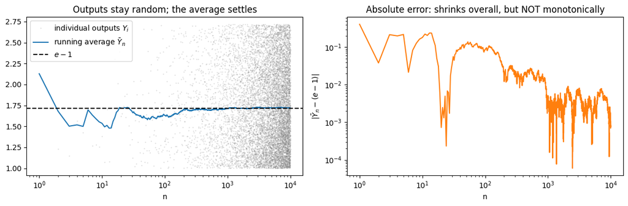

```python
fig, axes = plt.subplots(1, 2, figsize=(12, 4))

axes[0].plot(n_values, y_lln, ".", markersize=1, alpha=0.3, color="grey", label="individual outputs $Y_i$")
axes[0].plot(n_values, running_mean, color="C0", label=r"running average $\bar Y_n$")
axes[0].axhline(exact_integral, color="black", linestyle="--", label="$e-1$")
axes[0].set_xscale("log")
axes[0].set_xlabel("n")
axes[0].set_title("Outputs stay random; the average settles")
axes[0].legend()

axes[1].plot(n_values, running_abs_error, color="C1")
axes[1].set_xscale("log")
axes[1].set_yscale("log")
axes[1].set_xlabel("n")
axes[1].set_ylabel(r"$|\bar Y_n-(e-1)|$")
axes[1].set_title("Absolute error: shrinks overall, but NOT monotonically")

plt.tight_layout()
plt.show()
```

```python
error_went_up = np.diff(running_abs_error) > 0
print("Number of steps n -> n+1 :", len(error_went_up))
print("Steps where the absolute error INCREASED :", error_went_up.sum())
print("Fraction of steps where it increased     :", error_went_up.mean())
```

```
Number of steps n -> n+1 : 9999
Steps where the absolute error INCREASED : 4735
Fraction of steps where it increased     : 0.47354735473547355
```

**Questions:**

1. In the left panel, do the individual outputs $Y_i$ (grey dots) settle down as $n$ grows? Does the running average?
2. In the right panel, does the absolute error decrease at every step?
3. What fraction of steps made the error *larger*? What does this tell you about statement 2 in "What the LLN does **not** say"?

(`error_went_up` is an array of `True`/`False`. Summing it counts the `True` values; averaging it gives the fraction of `True`. We will use exactly this trick for probabilities in Demo 7.)

**One more look:** three independent runs of the same experiment. Each path is a different random stream.

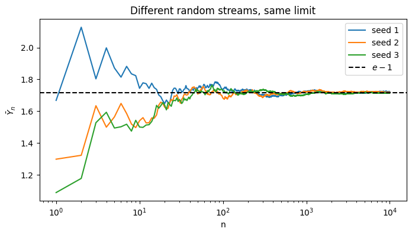

```python
fig, ax = plt.subplots(figsize=(8, 4))

path_rng = np.random.default_rng(1)
path_mean = np.cumsum(np.exp(path_rng.random(n_max))) / n_values
ax.plot(n_values, path_mean, label="seed 1")

path_rng = np.random.default_rng(2)
path_mean = np.cumsum(np.exp(path_rng.random(n_max))) / n_values
ax.plot(n_values, path_mean, label="seed 2")

path_rng = np.random.default_rng(3)
path_mean = np.cumsum(np.exp(path_rng.random(n_max))) / n_values
ax.plot(n_values, path_mean, label="seed 3")

ax.axhline(exact_integral, color="black", linestyle="--", label="$e-1$")
ax.set_xscale("log")
ax.set_xlabel("n")
ax.set_ylabel(r"$\bar Y_n$")
ax.set_title("Different random streams, same limit")
ax.legend()
plt.show()
```

Different streams give different paths — the estimate is random — but all paths approach the same fixed target.

The LLN tells us **where** the average goes. It does not yet tell us how far from the target a path typically is at, say, $n=100$. For that we need variance.

## Theory 3: Variance and sample standard deviation

### Population quantities (fixed, usually unknown)

$$ \sigma^2=\mathrm{Var}(Y)=\mathbb E\big[(Y-\mu)^2\big],\qquad \sigma=\sqrt{\sigma^2}. $$

$\sigma$ measures how spread out **individual outputs** are around their mean.

### Sample quantities (computed from simulated data)

$$ s^2=\frac{1}{n-1}\sum_{i=1}^n\big(Y_i-\bar Y\big)^2,\qquad s=\sqrt{s^2}. $$

### Why $n-1$ and not $n$?

We do not know $\mu$, so we measure deviations from $\bar Y$ instead. But $\bar Y$ is computed *from the same data*, and it is the number that makes $\sum(Y_i-c)^2$ as small as possible over all choices of $c$. So deviations from $\bar Y$ are, on average, a little **too small** compared with deviations from the true $\mu$. Dividing by $n-1$ instead of $n$ corrects this exactly: one can show $\mathbb E[s^2]=\sigma^2$ (for iid data with finite variance). Informally, after using the data once to estimate $\bar Y$, only $n-1$ of the deviations are "free" — they must add up to zero — hence "degrees of freedom".

### What `ddof` means in NumPy

`values.std(ddof=d)` computes

$$ \sqrt{\frac{1}{n-d}\sum_{i=1}^n (x_i-\bar x)^2 }. $$

- `ddof=0` (**NumPy's default**) divides by $n$: the SD of the numbers *treated as a whole population*.
- `ddof=1` divides by $n-1$: the **sample** SD, $s$. This is what we want, because our simulated outputs are a sample from the model.

Warning: **pandas** uses `ddof=1` by default (`Series.std()`), while **NumPy** uses `ddof=0` by default (`array.std()`). Always write `ddof=1` explicitly with NumPy.

## Theory 4: Standard deviation versus standard error

This is the most important distinction in the lab. We will return to it repeatedly.

|  | Standard deviation $s$ (or $\sigma$) | Standard error $\mathrm{SE}(\bar Y)$ |
| --- | --- | --- |
| Measures variation of … | **individual outputs** $Y_i$ | the **estimated mean** $\bar Y_n$ |
| Question it answers | "How different is one simulated day from another?" | "If I redid the whole simulation, how much would my *answer* move?" |
| As $n$ increases | settles to $\sigma$ — does **not** shrink to 0 | shrinks like $1/\sqrt n$ |

### Variance of a sample mean

Let $Y_1,\dots,Y_n$ be independent, each with variance $\sigma^2$. Two facts:

- $\mathrm{Var}(cZ)=c^2\,\mathrm{Var}(Z)$ for a constant $c$;
- for **independent** (in fact, uncorrelated suffices) random variables, $\mathrm{Var}(Z_1+\dots+Z_n)=\mathrm{Var}(Z_1)+\dots+\mathrm{Var}(Z_n)$.

Therefore

$$ \mathrm{Var}(\bar Y_n) =\mathrm{Var}\!\left(\frac1n\sum_{i=1}^n Y_i\right) =\frac1{n^2}\,\mathrm{Var}\!\left(\sum_{i=1}^n Y_i\right) =\frac1{n^2}\sum_{i=1}^n\mathrm{Var}(Y_i) =\frac1{n^2}\cdot n\sigma^2 =\frac{\sigma^2}{n}, $$

and so

$$ \boxed{\;\mathrm{SD}(\bar Y_n)=\frac{\sigma}{\sqrt n}\;} $$

The step $\mathrm{Var}(\sum Y_i)=\sum\mathrm{Var}(Y_i)$ is exactly where **independence** is used. If replications were not independent (for example, if we accidentally reused the same random numbers), this formula would be wrong.

### Estimated standard error

$\sigma$ is unknown, so we plug in the sample SD:

$$ \mathrm{SE}=\frac{s}{\sqrt n}. $$

### Intuition

Averaging $n$ independent noisy values cancels noise, but not perfectly: the noise in the *sum* grows like $\sqrt n$ (not like $n$), while we divide by $n$. Net effect: $\sqrt n/n=1/\sqrt n$.

**Question:** As $n$ increases, which quantity should shrink towards 0: the SD of the outputs, or the SE of the mean?

## Theory 5: The Central Limit Theorem (CLT)

### Why we need it

The LLN says $\bar Y_n\to\mu$. But in practice we stop at some finite $n$ and must report *how far off we might be*. For that we need to know the **distribution of the error** $\bar Y_n-\mu$. The CLT supplies it.

### A new idea: the sampling distribution

$\bar Y_n$ is computed from random outputs, so $\bar Y_n$ is itself a **random variable**. Imagine repeating the *entire* Monte Carlo experiment (all $n$ replications) many times, each time with fresh random numbers, and recording the $\bar Y_n$ from each experiment. The distribution of those recorded means is called the **sampling distribution of the estimator**.

- One observation from the distribution of $Y$ = **one replication** (one $e^{U}$, one simulated day).
- One observation from the sampling distribution of $\bar Y_n$ = **one whole experiment** of $n$ replications.

### Statement

Let $Y_1,Y_2,\dots$ be iid with mean $\mu$ and finite variance $0<\sigma^2<\infty$. Then

$$ Z_n=\frac{\bar Y_n-\mu}{\sigma/\sqrt n}\;\overset{d}{\longrightarrow}\;N(0,1), $$

which means $\mathbb P(Z_n\le z)\to\Phi(z)$ for every $z$, where $\Phi$ is the standard Normal CDF. Informally, for sufficiently large $n$,

$$ \bar Y_n\;\approx\;N\!\left(\mu,\ \frac{\sigma^2}{n}\right). $$

The same limit holds if we replace the unknown $\sigma$ by the sample SD $s$ (because $s\to\sigma$ by the LLN; the formal tool is Slutsky's theorem). This is what licenses using $s/\sqrt n$ in practice.

### Remarks

1. **The original output $Y$ does not need to be Normal.** $e^U$ is not Normal (it is not even symmetric), and daily profit need not be Normal. The CLT is about the *average*, not the individual values.
2. It is the **sampling distribution of $\bar Y_n$** that becomes approximately Normal — the histogram of many repeated *means*, not the histogram of outputs.
3. "Sufficiently large $n$" is not a fixed number. The more skewed or heavy-tailed $Y$ is, the larger $n$ must be. For the smooth, bounded $e^U$, $n=100$ is plenty; for a rare-event indicator it may not be.
4. The CLT needs **finite variance**. (Every model in this lab satisfies this.)

### LLN versus CLT

|  | LLN | CLT |
| --- | --- | --- |
| Tells us | **where** $\bar Y_n$ goes | **how** $\bar Y_n$ is spread around where it goes |
| Formula | $\bar Y_n\to\mu$ | $\dfrac{\bar Y_n-\mu}{\sigma/\sqrt n}\approx N(0,1)$ |
| Licenses the statement | "the answer is right in the long run" | "here is an error bar for this $n$" |

We will *see* the CLT in Demo 3 by repeating an experiment 500 times.

## Theory 6: The approximate 95% confidence interval

### Where 1.96 comes from

For $Z\sim N(0,1)$,

$$ \mathbb P(-1.96<Z<1.96)\approx0.95 , $$

equivalently $\Phi(1.96)\approx0.975$: 2.5% in each tail. Let us check this two ways — with an exact formula, and with Monte Carlo itself.

```python
math.erf(1.96 / np.sqrt(2))
```

```
0.9500042097035591
```

```python
z_rng = np.random.default_rng(DEMO_SEED + 3)
z_draws = z_rng.standard_normal(1_000_000)
inside = (z_draws > -1.96) & (z_draws < 1.96)
inside.mean()
```

```
np.float64(0.949619)
```

### From the CLT to the interval

By the CLT, approximately,

$$ \mathbb P\!\left(-1.96<\frac{\bar Y_n-\mu}{\sigma/\sqrt n}<1.96\right)\approx0.95 . $$

Multiply through by $\sigma/\sqrt n$ and rearrange the inequalities so that $\mu$ is in the middle:

$$ \mathbb P\!\left(\bar Y_n-1.96\frac{\sigma}{\sqrt n}<\mu<\bar Y_n+1.96\frac{\sigma}{\sqrt n}\right)\approx0.95 . $$

Replace $\sigma$ by $s$:

$$ \boxed{\;\bar Y_n\pm1.96\,\frac{s}{\sqrt n}\;} $$

### The parts of the interval

| Name | Formula | Meaning |
| --- | --- | --- |
| estimate | $\bar Y_n$ | our best single guess of $\mu$ |
| standard error | $\mathrm{SE}=s/\sqrt n$ | typical size of the estimation error |
| margin of error | $1.96\times\mathrm{SE}$ | half-width of the interval |
| lower endpoint | $\bar Y_n-1.96\,\mathrm{SE}$ |  |
| upper endpoint | $\bar Y_n+1.96\,\mathrm{SE}$ |  |
| width | $2\times1.96\,\mathrm{SE}$ | total length of the interval |

### What "95%" means

Look carefully at the probability statement above: the **random** quantities are $\bar Y_n$ and $s$, i.e. the **endpoints**. The target $\mu$ is fixed.

> If we repeated the entire procedure many times — new random numbers, new $\bar Y_n$, new $s$, new interval — then about 95% of the intervals constructed this way would contain the true mean $\mu$.

Once we have computed one interval, say $[1.19, 1.76]$, it either contains $\mu$ or it does not. The 95% is a property of the **procedure**, not of one particular interval. We will check this by simulation in Demo 3.

### A CI for the mean is not a range for individual outputs

The CI is about $\mu=\mathbb E[Y]$. It is **not** a range that contains 95% of individual outputs $Y_i$. Individual outputs are spread with SD $\sigma$; the CI has half-width $1.96\,\sigma/\sqrt n$, which is far smaller when $n$ is large. Confusing these two is the most common error in Lab 4 recommendations.

## Demo 2: SD, SE and a confidence interval

We return to the ten values `h_small` from Demo 1 and compute every piece of the interval in its own cell.

```python
h_small
```

```
array([1.01629173, 1.16011466, 1.58259608, 1.27901662, 1.07686185,
       1.87768386, 1.10911214, 1.23773964, 2.19769189, 2.19782939])
```

**Step 1 — sample SD** $\;s=\sqrt{\frac1{n-1}\sum(h_i-\bar h)^2}$ : how different the ten outputs are *from each other*.

```python
sample_sd = h_small.std(ddof=1)
sample_sd
```

```
np.float64(0.4612941152726655)
```

**Step 2 — sample size and standard error** $\;\mathrm{SE}=s/\sqrt n$ : how much the *average* of ten such outputs would typically move from experiment to experiment.

```python
n = len(h_small)
n
```

```
10
```

```python
standard_error = sample_sd / np.sqrt(n)
standard_error
```

```
np.float64(0.14587400754938873)
```

**Step 3 — margin of error** $\;1.96\times\mathrm{SE}$

```python
z = 1.96
margin = z * standard_error
margin
```

```
np.float64(0.2859130547968019)
```

**Step 4 — endpoints** $\;\bar h\pm\text{margin}$

```python
lower = estimate - margin
lower
```

```
np.float64(1.1875807297345324)
```

```python
upper = estimate + margin
upper
```

```
np.float64(1.7594068393281361)
```

```python
ci_width = upper - lower
ci_width
```

```
np.float64(0.5718261095936037)
```

**Step 5 — collect everything in one table** (only now, after each number has been seen on its own).

```python
pd.Series({
    "n": n,
    "estimate  h_bar": estimate,
    "sample SD  s": sample_sd,
    "standard error  s/sqrt(n)": standard_error,
    "margin  1.96*SE": margin,
    "lower": lower,
    "upper": upper,
    "width": ci_width,
    "exact value e - 1": exact_integral,
})
```

```
n                            10.000000
estimate  h_bar               1.473494
sample SD  s                  0.461294
standard error  s/sqrt(n)     0.145874
margin  1.96*SE               0.285913
lower                         1.187581
upper                         1.759407
width                         0.571826
exact value e - 1             1.718282
dtype: float64
```

**Note.** With $n=10$ the Normal approximation behind 1.96 is rough, and $s$ is itself a noisy estimate of $\sigma$. The recipe is designed for large $n$; we use $n=10$ here only so that every number fits on the screen.

**Questions:**

1. Does this interval contain the exact value $e-1$, even though the estimate itself was noticeably off?
2. Is the sample SD $s$ the uncertainty in our estimate? If not, which number is, and roughly how many times smaller is it here?

### Now repeat the whole calculation for a larger sample

We now want the same numbers for $n=10$ and $n=100$. First we do it the long way: copy the calculation and change $n$.

```python
rng = np.random.default_rng(DEMO_SEED)

n = 10
u = rng.random(n)
h_values = np.exp(u)
estimate = h_values.mean()
sample_sd = h_values.std(ddof=1)
standard_error = sample_sd / np.sqrt(n)
margin = 1.96 * standard_error
print(f"n = {n}: estimate = {estimate:.4f}, SD = {sample_sd:.4f}, SE = {standard_error:.4f}, "
      f"CI = [{estimate - margin:.4f}, {estimate + margin:.4f}]")
```

```
n = 10: estimate = 1.4735, SD = 0.4613, SE = 0.1459, CI = [1.1876, 1.7594]
```

```python
n = 100
u = rng.random(n)
h_values = np.exp(u)
estimate = h_values.mean()
sample_sd = h_values.std(ddof=1)
standard_error = sample_sd / np.sqrt(n)
margin = 1.96 * standard_error
print(f"n = {n}: estimate = {estimate:.4f}, SD = {sample_sd:.4f}, SE = {standard_error:.4f}, "
      f"CI = [{estimate - margin:.4f}, {estimate + margin:.4f}]")
```

```
n = 100: estimate = 1.7094, SD = 0.5239, SE = 0.0524, CI = [1.6068, 1.8121]
```

We are about to repeat *exactly* the same calculation for $n=1000$ and $n=10000$. Copying the block again and again is tedious, and dangerous: if we fix a mistake in one copy we must remember to fix it in every copy. This repeated structure is why a **loop** is useful.

Note that the second block did **not** re-create `rng`, so the 100 uniforms for $n=100$ are the *next* 100 numbers in the stream, not the first 10 again.

### Python: the `for` loop

Start with a loop that does nothing but announce the value of `n`.

```python
for n in [10, 100, 1000, 10000]:
    print("This time round the loop, n =", n)
```

```
This time round the loop, n = 10
This time round the loop, n = 100
This time round the loop, n = 1000
This time round the loop, n = 10000
```

How to read it:

- `[10, 100, 1000, 10000]` is a **list**: four values in order.
- `for n in ...:` means "take the first value, call it `n`, run the indented block; then take the next value, call it `n`, run the block again; … until the list is used up".
- `n` is an ordinary variable. It is **overwritten** on each pass (**iteration**): 10, then 100, then 1000, then 10000.
- The **colon** `:` ends the `for` line and says "the block follows".
- The **indentation** (4 spaces) defines the block. Every indented line is repeated; the first line that is *not* indented is outside the loop and runs once, after the loop has finished.

### Now the loop

Compare it line by line with the two manual blocks above: the body of the loop is the manual block, and the list replaces "change $n$ by hand".

```python
rng = np.random.default_rng(DEMO_SEED)
integration_rows = []

for n in [10, 100, 1000, 10000]:
    u = rng.random(n)
    h_values = np.exp(u)
    estimate = h_values.mean()
    sample_sd = h_values.std(ddof=1)
    standard_error = sample_sd / np.sqrt(n)
    margin = 1.96 * standard_error
    integration_rows.append({
        "n": n,
        "estimate": estimate,
        "absolute_error": abs(estimate - exact_integral),
        "sample_sd": sample_sd,
        "standard_error": standard_error,
        "lower": estimate - margin,
        "upper": estimate + margin,
        "ci_width": 2 * margin,
    })
```

```python
integration_rows[0]
```

```
{'n': 10,
 'estimate': np.float64(1.4734937845313343),
 'absolute_error': np.float64(0.2447880439277108),
 'sample_sd': np.float64(0.4612941152726655),
 'standard_error': np.float64(0.14587400754938873),
 'lower': np.float64(1.1875807297345324),
 'upper': np.float64(1.7594068393281361),
 'ci_width': np.float64(0.5718261095936038)}
```

```python
integration_demo = pd.DataFrame(integration_rows)
integration_demo
```

|  | n | estimate | absolute_error | sample_sd | standard_error | lower | upper | ci_width |
| --- | --- | --- | --- | --- | --- | --- | --- | --- |
| 0 | 10 | 1.473494 | 0.244788 | 0.461294 | 0.145874 | 1.187581 | 1.759407 | 0.571826 |
| 1 | 100 | 1.709444 | 0.008838 | 0.523884 | 0.052388 | 1.606763 | 1.812125 | 0.205363 |
| 2 | 1000 | 1.714504 | 0.003778 | 0.481991 | 0.015242 | 1.684630 | 1.744378 | 0.059748 |
| 3 | 10000 | 1.717911 | 0.000371 | 0.492058 | 0.004921 | 1.708267 | 1.727555 | 0.019289 |

**Predict before looking closely at the table:**

1. Must the absolute error decrease in every row?
2. Which column should stay roughly constant as $n$ grows, and which should shrink?
3. By roughly what factor should the SE shrink from one row to the next? (Each row has 10 times as many replications.)

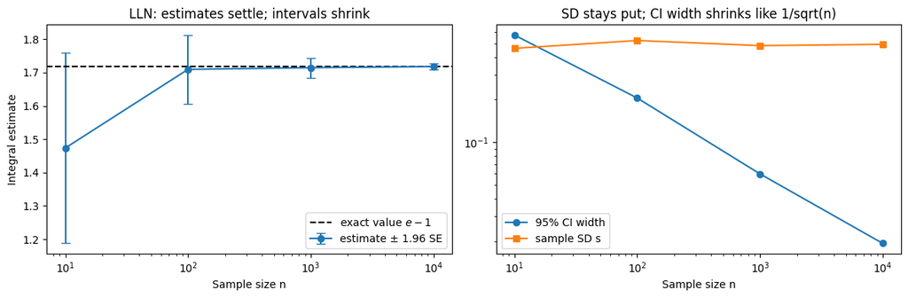

```python
fig, axes = plt.subplots(1, 2, figsize=(12, 4))

axes[0].errorbar(integration_demo["n"], integration_demo["estimate"],
                 yerr=1.96 * integration_demo["standard_error"],
                 marker="o", capsize=4, label="estimate ± 1.96 SE")
axes[0].axhline(exact_integral, color="black", linestyle="--", label="exact value $e-1$")
axes[0].set_xscale("log")
axes[0].set_xlabel("Sample size n")
axes[0].set_ylabel("Integral estimate")
axes[0].set_title("LLN: estimates settle; intervals shrink")
axes[0].legend()

axes[1].plot(integration_demo["n"], integration_demo["ci_width"], marker="o", label="95% CI width")
axes[1].plot(integration_demo["n"], integration_demo["sample_sd"], marker="s", label="sample SD s")
axes[1].set_xscale("log")
axes[1].set_yscale("log")
axes[1].set_xlabel("Sample size n")
axes[1].set_title("SD stays put; CI width shrinks like 1/sqrt(n)")
axes[1].legend()

plt.tight_layout()
plt.show()
```

**Interpretation.**

- On a log–log plot, a quantity proportional to $n^{-1/2}$ is a straight line of slope $-1/2$: every factor 10 in $n$ drops the width by a factor $\sqrt{10}\approx3.16$. The CI width follows that line; the SD is flat.
- Reducing the SE by a factor of 10 needs about **100 times** as many replications. Monte Carlo is reliable but slow.
- A larger sample reduces the *typical* error. It does not guarantee that any particular larger-$n$ estimate is closer to the truth.

## Demo 3: One estimate has a sampling distribution (seeing the CLT)

**Question:** "If I rerun the whole $n=100$ experiment with fresh uniforms, do I get the same answer? How different could it be?"

### Experiment A — 100 uniforms, one estimate

```python
experiment_rng = np.random.default_rng(DEMO_SEED + 4)

u_A = experiment_rng.random(100)
estimate_A = np.exp(u_A).mean()
print(f"Experiment A: estimate = {estimate_A:.5f}")
```

```
Experiment A: estimate = 1.66226
```

### Experiment B — a *fresh* 100 uniforms, same method

```python
u_B = experiment_rng.random(100)
estimate_B = np.exp(u_B).mean()
print(f"Experiment B: estimate = {estimate_B:.5f}")
print(f"Difference A - B      = {estimate_A - estimate_B:.5f}")
```

```
Experiment B: estimate = 1.68096
Difference A - B      = -0.01871
```

**Question:** Why are the two estimates different if they are estimating the same quantity?

### The real function: one row per repeated experiment

`repeated_estimates` repeats the whole $n$-sample experiment many times and records, for each repetition, the estimate, its standard error and its confidence interval.

```python
def repeated_estimates(n, repeats, rng, z=1.96):
    """Repeat the whole n-sample Monte Carlo experiment `repeats` times.

    Returns a DataFrame with one row per experiment: estimate, SE and interval.
    """
    rows = []
    for _ in range(repeats):
        u = rng.random(n)
        h = np.exp(u)
        estimate = h.mean()
        standard_error = h.std(ddof=1) / np.sqrt(n)
        rows.append({
            "estimate": estimate,
            "standard_error": standard_error,
            "lower": estimate - z * standard_error,
            "upper": estimate + z * standard_error,
        })
    return pd.DataFrame(rows)
```

- **Parameters:** `n` (replications per experiment), `repeats` (how many experiments), `rng` (the generator to draw from), `z` (critical value, default 1.96).
- `for _ in range(repeats):` — we need to repeat `repeats` times but never use the counter, so by convention we name it `_`.
- **Why is `rng` an argument, not created inside?** If the function did `rng = np.random.default_rng(DEMO_SEED)` inside the loop, *every experiment would use the same 100 uniforms* and all rows would be identical. Passing one generator in lets it move forward through the stream, so each experiment gets new random numbers, while the whole run is still reproducible from the one seed chosen outside.

**Always test a new function on a tiny case first.** Three experiments of size 10:

```python
tiny_rng = np.random.default_rng(DEMO_SEED + 5)
repeated_estimates(n=10, repeats=3, rng=tiny_rng)
```

|  | estimate | standard_error | lower | upper |
| --- | --- | --- | --- | --- |
| 0 | 1.729188 | 0.074175 | 1.583806 | 1.874571 |
| 1 | 1.828716 | 0.159162 | 1.516759 | 2.140674 |
| 2 | 1.819976 | 0.182180 | 1.462903 | 2.177048 |

**Question:** What does one row represent? Why do the three intervals differ in both centre *and* width?

### What does the CLT predict for this problem? — derive $\sigma$ exactly

For $Y=e^U$, $U\sim\mathrm{Uniform}(0,1)$:

**Mean.** $$ \mathbb E[Y]=\int_0^1e^u\,du=e-1\approx1.718282. $$

**Second moment.** $$ \mathbb E[Y^2]=\mathbb E[e^{2U}]=\int_0^1e^{2u}\,du=\left[\tfrac12e^{2u}\right]_0^1=\frac{e^2-1}{2}\approx3.194528. $$

**Variance.** $$ \sigma^2=\mathrm{Var}(Y)=\mathbb E[Y^2]-(\mathbb E[Y])^2=\frac{e^2-1}{2}-(e-1)^2\approx0.242036, \qquad \sigma\approx0.491971 . $$

**Prediction for the sampling distribution.** $$ \mathrm{SD}(\bar Y_{100})=\frac{\sigma}{\sqrt{100}}=\frac{\sigma}{10}\approx0.049197, \qquad \mathrm{SD}(\bar Y_{400})=\frac{\sigma}{\sqrt{400}}=\frac{\sigma}{20}\approx0.024599 . $$

Going from $n=100$ to $n=400$ multiplies $n$ by 4, so the SD should be multiplied by $1/\sqrt4=\tfrac12$:

$$ n\times4\quad\Longrightarrow\quad \mathrm{SE}\times\tfrac12 . $$

This is a **falsifiable prediction**. Let us test it.

```python
E_Y = np.e - 1
E_Y2 = (np.e ** 2 - 1) / 2
var_h = E_Y2 - E_Y ** 2
sigma_h = np.sqrt(var_h)

pd.Series({
    "E[Y] = e - 1": E_Y,
    "E[Y^2] = (e^2 - 1)/2": E_Y2,
    "Var(Y)": var_h,
    "sigma = SD(Y)": sigma_h,
    "predicted SD of estimate, n = 100": sigma_h / np.sqrt(100),
    "predicted SD of estimate, n = 400": sigma_h / np.sqrt(400),
})
```

```
E[Y] = e - 1                         1.718282
E[Y^2] = (e^2 - 1)/2                 3.194528
Var(Y)                               0.242036
sigma = SD(Y)                        0.491971
predicted SD of estimate, n = 100    0.049197
predicted SD of estimate, n = 400    0.024599
dtype: float64
```

**Predict:** we will run 500 experiments at $n=100$. Roughly what fraction of the 500 estimates should lie within $\pm0.049$ of $1.718$? Within $\pm0.098$?

### Now 500 experiments at $n=100$, and 500 at $n=400$

```python
repeat_rng = np.random.default_rng(DEMO_SEED)

demo_repeats_100 = repeated_estimates(n=100, repeats=500, rng=repeat_rng)
demo_repeats_400 = repeated_estimates(n=400, repeats=500, rng=repeat_rng)

demo_repeats_100.head()
```

|  | estimate | standard_error | lower | upper |
| --- | --- | --- | --- | --- |
| 0 | 1.707596 | 0.052044 | 1.605590 | 1.809601 |
| 1 | 1.681722 | 0.046258 | 1.591056 | 1.772387 |
| 2 | 1.689628 | 0.051453 | 1.588781 | 1.790476 |
| 3 | 1.761977 | 0.049867 | 1.664238 | 1.859717 |
| 4 | 1.765497 | 0.049617 | 1.668248 | 1.862747 |

```python
repeated_estimates_100 = demo_repeats_100["estimate"].to_numpy()
repeated_estimates_400 = demo_repeats_400["estimate"].to_numpy()

sd_of_estimates_100 = repeated_estimates_100.std(ddof=1)
sd_of_estimates_400 = repeated_estimates_400.std(ddof=1)

clt_demo = pd.DataFrame({
    "n": [100, 400],
    "mean of 500 estimates": [repeated_estimates_100.mean(), repeated_estimates_400.mean()],
    "SD of 500 estimates (observed)": [sd_of_estimates_100, sd_of_estimates_400],
    "CLT prediction sigma/sqrt(n)": [sigma_h / np.sqrt(100), sigma_h / np.sqrt(400)],
})
clt_demo.round(5)
```

|  | n | mean of 500 estimates | SD of 500 estimates (observed) | CLT prediction sigma/sqrt(n) |
| --- | --- | --- | --- | --- |
| 0 | 100 | 1.71734 | 0.04876 | 0.0492 |
| 1 | 400 | 1.71762 | 0.02558 | 0.0246 |

```python
print(f"Observed ratio  SD(n=100) / SD(n=400) = {sd_of_estimates_100 / sd_of_estimates_400:.3f}")
print(f"Predicted ratio sqrt(400/100)         = {np.sqrt(400 / 100):.3f}")
```

```
Observed ratio  SD(n=100) / SD(n=400) = 1.906
Predicted ratio sqrt(400/100)         = 2.000
```

```python
distance_from_truth = np.abs(repeated_estimates_100 - exact_integral)
one_sd = sigma_h / np.sqrt(100)
print(f"fraction of the 500 estimates within 1 predicted SD ({one_sd:.3f}) of e-1 : {np.mean(distance_from_truth < one_sd):.3f}")
print(f"fraction within 2 predicted SDs ({2 * one_sd:.3f})                        : {np.mean(distance_from_truth < 2 * one_sd):.3f}")
print("Normal-distribution benchmarks: about 0.683 and 0.954")
```

```
fraction of the 500 estimates within 1 predicted SD (0.049) of e-1 : 0.682
fraction within 2 predicted SDs (0.098)                        : 0.958
Normal-distribution benchmarks: about 0.683 and 0.954
```

**Question:** The observed SDs are close to the CLT predictions, but the observed ratio is not exactly 2. Why should we not expect it to be exactly 2 in a finite simulation?

### The key picture: distribution of individual outputs vs distribution of repeated means

**Question (think before running the next cell):** In the left panel each observation is one $e^{U_i}$. In the right panel each observation is one whole experiment's average of 100 of them. Which will look more like a bell curve? Which will be wider?

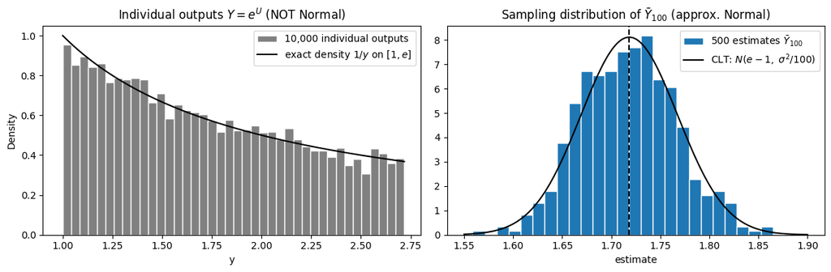

```python
fig, axes = plt.subplots(1, 2, figsize=(12, 4))

axes[0].hist(y_lln, bins=40, density=True, color="grey", edgecolor="white",
             label="10,000 individual outputs")
y_grid = np.linspace(1, np.e, 200)
axes[0].plot(y_grid, 1 / y_grid, color="black", label="exact density $1/y$ on $[1,e]$")
axes[0].set_xlim(0.9, 2.8)
axes[0].set_title(r"Individual outputs $Y=e^U$ (NOT Normal)")
axes[0].set_xlabel("y")
axes[0].set_ylabel("Density")
axes[0].legend()

axes[1].hist(repeated_estimates_100, bins=25, density=True, color="tab:blue", edgecolor="white",
             label=r"500 estimates $\bar Y_{100}$")
m_grid = np.linspace(1.55, 1.9, 300)
predicted_sd = sigma_h / np.sqrt(100)
normal_curve = np.exp(-0.5 * ((m_grid - exact_integral) / predicted_sd) ** 2) / (predicted_sd * np.sqrt(2 * np.pi))
axes[1].plot(m_grid, normal_curve, color="black", label=r"CLT: $N(e-1,\ \sigma^2/100)$")
axes[1].axvline(exact_integral, color="black", linestyle="--")
axes[1].set_title(r"Sampling distribution of $\bar Y_{100}$ (approx. Normal)")
axes[1].set_xlabel("estimate")
axes[1].legend()

plt.tight_layout()
plt.show()
```

**Remarks.**

1. The left histogram is of **outputs**: $Y=e^U$ has density $1/y$ on $[1,e]$ (derive it yourself: $\mathbb P(Y\le y)=\mathbb P(U\le\ln y)=\ln y$, then differentiate). It is decreasing and skewed — nothing like a bell curve.
2. The right histogram is of **averages of 100 outputs**. It is symmetric and bell-shaped, and the black curve is not fitted to the data — it is the CLT's *prediction* $N(e-1,\sigma^2/100)$ from the formula we derived. That is the Central Limit Theorem.
3. Horizontal scales: the left spans about 1.7 units; the right spans about 0.3 units. The ratio of spreads is $\sqrt{100}=10$.

**Question:** Why can individual outputs be non-Normal while sample means look Normal?

### Coverage: do about 95% of the intervals contain the true value?

For each of the 500 experiments we computed an interval. The truth $e-1$ is fixed. Count how many intervals contain it.

First, see what the check looks like for the first five experiments.

```python
first_five = demo_repeats_100.head().copy()
first_five["lower <= truth"] = first_five["lower"] <= exact_integral
first_five["truth <= upper"] = exact_integral <= first_five["upper"]
first_five["contains truth"] = first_five["lower <= truth"] & first_five["truth <= upper"]
first_five
```

|  | estimate | standard_error | lower | upper | lower <= truth | truth <= upper | contains truth |
| --- | --- | --- | --- | --- | --- | --- | --- |
| 0 | 1.707596 | 0.052044 | 1.605590 | 1.809601 | True | True | True |
| 1 | 1.681722 | 0.046258 | 1.591056 | 1.772387 | True | True | True |
| 2 | 1.689628 | 0.051453 | 1.588781 | 1.790476 | True | True | True |
| 3 | 1.761977 | 0.049867 | 1.664238 | 1.859717 | True | True | True |
| 4 | 1.765497 | 0.049617 | 1.668248 | 1.862747 | True | True | True |

```python
contains_100 = (demo_repeats_100["lower"] <= exact_integral) & (exact_integral <= demo_repeats_100["upper"])
contains_400 = (demo_repeats_400["lower"] <= exact_integral) & (exact_integral <= demo_repeats_400["upper"])

pd.Series({
    "coverage at n = 100 (fraction of 500 intervals containing e - 1)": contains_100.mean(),
    "coverage at n = 400": contains_400.mean(),
    "number of intervals that MISSED at n = 100": (~contains_100).sum(),
})
```

```
coverage at n = 100 (fraction of 500 intervals containing e - 1)     0.946
coverage at n = 400                                                  0.934
number of intervals that MISSED at n = 100                          27.000
dtype: float64
```

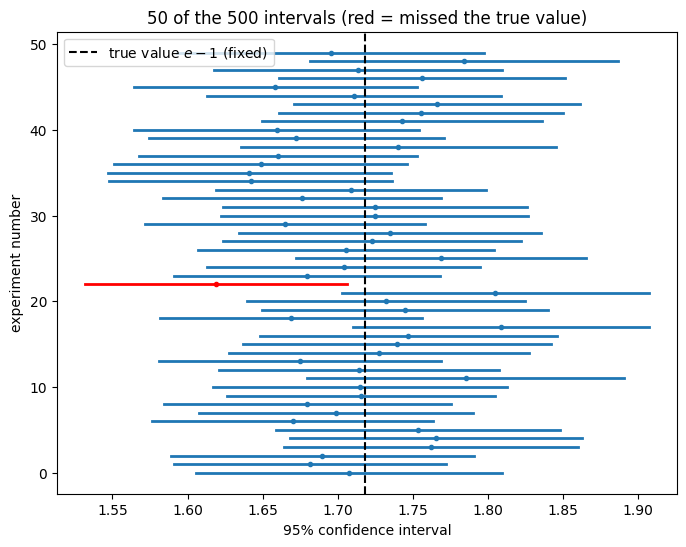

```python
fig, ax = plt.subplots(figsize=(8, 6))
for k in range(50):
    row = demo_repeats_100.iloc[k]
    hit = (row["lower"] <= exact_integral) and (exact_integral <= row["upper"])
    colour = "C0" if hit else "red"
    ax.plot([row["lower"], row["upper"]], [k, k], color=colour, linewidth=2)
    ax.plot(row["estimate"], k, "o", color=colour, markersize=3)
ax.axvline(exact_integral, color="black", linestyle="--", label="true value $e-1$ (fixed)")
ax.set_xlabel("95% confidence interval")
ax.set_ylabel("experiment number")
ax.set_title("50 of the 500 intervals (red = missed the true value)")
ax.legend()
plt.show()
```

**Remarks.**

1. The **intervals move; the target does not.** Each horizontal line is one experiment's interval. The vertical dashed line never moves.
2. About 95% of the 500 intervals contain the truth. Coverage is itself estimated from 500 intervals, so it has sampling error of about $\sqrt{0.95\times0.05/500}\approx0.01$. Values between roughly 0.93 and 0.97 are consistent with 95%; do not present 0.934 as a failure of the method.
3. This is exactly what "95% confidence" means: a statement about the long-run behaviour of the **procedure**.

**Question:** "Which of these 500 answers would you have reported if you had run the experiment once?"

**Lab link:** Lab 4 Parts A2–A3 ask you to reproduce this for $\int_0^1x^2\,dx=1/3$, where $\sigma_h=\sqrt{4/45}\approx0.29814$.

## Theory 7: The Monte Carlo convergence rate $O(n^{-1/2})$

### The rate

$$ \mathrm{SE}(\bar Y_n)=\frac{\sigma}{\sqrt n}=O\!\left(n^{-1/2}\right). $$

"$O(n^{-1/2})$" means: bounded by a constant times $n^{-1/2}$. Here the constant is $\sigma$ — it depends on the *problem* (how variable the output is), while the exponent $-1/2$ is the same for every Monte Carlo problem.

### Practical consequences

| Multiply the number of replications by | SE is multiplied by |
| --- | --- |
| 4 | $1/\sqrt4=1/2$ |
| 10 | $1/\sqrt{10}\approx0.316$ |
| 100 | $1/10$ |
| 10,000 | $1/100$ |

**Each extra correct decimal place costs 100 times as many replications.**

### How many replications for a target precision?

To get a 95% half-width at most $\varepsilon$: $1.96\,\sigma/\sqrt n\le\varepsilon$, i.e.

$$ n\;\ge\;\left(\frac{1.96\,\sigma}{\varepsilon}\right)^2 . $$

```python
for target_half_width in [0.01, 0.001]:
    n_needed = (1.96 * sigma_h / target_half_width) ** 2
    print(f"half-width {target_half_width}: need n >= {n_needed:,.0f}")
```

```
half-width 0.01: need n >= 9,298
half-width 0.001: need n >= 929,804
```

Two correct decimals cost about 9,300 replications; three cost about 930,000 — 100 times more.

### More replications reduce Monte Carlo error. They do not repair a bad model.

There are two different kinds of uncertainty in any simulation study:

|  | **Monte Carlo (sampling) error** | **Model error** |
| --- | --- | --- |
| Source | finite number of random replications | wrong or simplified assumptions (distributions, parameters, missing features) |
| Measured by | SE and CI | not measured by SE or CI at all |
| Reduced by | more replications | better data, validation, sensitivity analysis |

A confidence interval says: "*if the model is right*, this is how precisely we have computed its expected output." It says nothing about whether the model is right.

**Question:** "If the model assumptions are wrong, will 1,000,000 replications fix them?"

## Demo 4: From mathematical integration to a business decision

Monte Carlo does not change when the model becomes more realistic. Only $X$ and $h$ change.

$$ X\;\longrightarrow\;h(X) $$

|  | Integration | Kiosk |
| --- | --- | --- |
| Random input $X$ | $U\sim\mathrm{Uniform}(0,1)$ | today's demand $D$ **and** each customer's spend $S_1,\dots,S_D$ |
| Model $h$ | $h(U)=e^U$ | $h(X)=\text{revenue}-\text{cost}=$ today's profit $H$ |
| One replication | one uniform | one simulated day |
| Target(s) | $\mathbb E[e^U]$ | $\mathbb E[H]$ and $\mathbb P(H<0)$ |
| Estimator | $\frac1n\sum e^{U_i}$ | $\frac1n\sum H_i$ and $\frac1n\sum\mathbf 1\{H_i<0\}$ |

### The decision

A campus smoothie kiosk is considering a digital coupon. It may attract more customers but lowers spend per customer and costs money to run. The decision uses two targets:

$$ \mathbb E[H]\qquad\text{and}\qquad \mathbb P(H<0)=\mathbb E\big[\mathbf 1\{H<0\}\big]. $$

The first measures **expected return**; the second measures **downside frequency** (how often the kiosk loses money). The second target is also an expectation — of an indicator — so the same Monte Carlo machinery applies (Demo 7).

| Component | Regular day | Coupon day |
| --- | --- | --- |
| Demand $D$ | rounded Normal(70, 10), clipped at 0 | rounded Normal(86, 16), clipped at 0 |
| Spend per customer $S_j$ | Normal(6.0, 0.8), clipped at 0 | Normal(5.7, 0.9), clipped at 0 |
| Variable cost per customer | 2.5 | 2.5 |
| Fixed cost | 180 | 180 |
| Campaign cost | 0 | 30 |

**Question:** Which entries are random inputs, which are fixed parameters, and which quantities are outputs?

### Python lesson: dictionaries

We store each scenario's assumptions in a **dictionary**: a collection of `key: value` pairs, written inside `{ }`. We look up a value by its key with square brackets, e.g. `regular["demand_mean"]`.

```python
regular = {
    "demand_mean": 70,
    "demand_sd": 10,
    "spend_mean": 6.0,
    "spend_sd": 0.8,
    "variable_cost": 2.5,
    "fixed_cost": 180,
    "campaign_cost": 0,
}

coupon = {
    "demand_mean": 86,
    "demand_sd": 16,
    "spend_mean": 5.7,
    "spend_sd": 0.9,
    "variable_cost": 2.5,
    "fixed_cost": 180,
    "campaign_cost": 30,
}
```

```python
regular["demand_mean"]
```

```
70
```

## Demo 5: Build one regular day **by hand**

This is the structural heart of the lab. In Lab 4 the daily-profit model is **provided**; you are not asked to build it, but you must be able to explain every line. So we build one day step by step, and only then package it into a function.

The model for one day:

$$ D=\max\big(0,\ \mathrm{round}(N(\mu_D,\sigma_D))\big),\qquad S_j=\max\big(0,\ N(\mu_S,\sigma_S)\big),\ j=1,\dots,D, $$

$$ R=\sum_{j=1}^{D}S_j,\qquad C=c_v D+C_{\text{fixed}}+C_{\text{campaign}},\qquad H=R-C. $$

```python
manual_rng = np.random.default_rng(DEMO_SEED)

demand_mean = regular["demand_mean"]
demand_sd = regular["demand_sd"]
print("demand mean =", demand_mean, "   demand SD =", demand_sd)
```

```
demand mean = 70    demand SD = 10
```

### Demand, one operation at a time

**Step 1 — raw Normal draw.** A Normal random variable is continuous: it gives numbers like 73.02, not whole customers.

```python
raw_demand = manual_rng.normal(demand_mean, demand_sd)
raw_demand
```

```
73.02264359400246
```

**Step 2 — round to the nearest whole number.** Customers come in whole numbers.

```python
rounded_demand = round(raw_demand)
rounded_demand
```

```
73
```

**Step 3 — make sure the result is an integer type.** In current Python, `round(x)` already returns an integer, but some older NumPy versions returned a float such as `73.0`. The next step uses demand as an *array size*, which must be an integer, so the model code writes `int(...)` explicitly as a safeguard.

```python
integer_demand = int(rounded_demand)
print(integer_demand, type(raw_demand), type(integer_demand))
```

```
73 <class 'float'> <class 'int'>
```

**Step 4 — clip at zero.** A Normal draw can in principle be negative, but negative customers make no sense (and NumPy refuses a negative array size). `max(0, d)` returns the larger of 0 and $d$: it leaves positive values alone and replaces negatives by 0.

```python
demand = max(0, integer_demand)
demand
```

```
73
```

```python
print("max(0, 73) =", max(0, 73), "   max(0, -4) =", max(0, -4))
print("round(2.5) =", round(2.5), "   round(3.5) =", round(3.5), "   <- Python rounds exact halves to the EVEN neighbour")
```

```
max(0, 73) = 73    max(0, -4) = 0
round(2.5) = 2    round(3.5) = 4    <- Python rounds exact halves to the EVEN neighbour
```

(The half-to-even rule has probability zero of mattering for a continuous draw, but you may be surprised if you test `round(2.5)` yourself.)

### Reading nested Python: the compact version

The provided model does all four steps in one line:

```
demand = max(0, int(round(rng.normal(demand_mean, demand_sd))))
```

Read nested function calls **from the inside out**:

1. `rng.normal(demand_mean, demand_sd)` → raw draw, e.g. 73.02
2. `round( ... )` → 73
3. `int( ... )` → 73 as an integer
4. `max(0, ... )` → 73 (or 0 if it were negative)

Check that it gives exactly the same demand when we restart the same stream:

```python
check_rng = np.random.default_rng(DEMO_SEED)
demand_compact = max(
    0,
    int(
        round(
            check_rng.normal(demand_mean, demand_sd)
        )
    )
)
print("step-by-step demand:", demand, "   compact demand:", demand_compact)
```

```
step-by-step demand: 73    compact demand: 73
```

### Spending: one random value per customer

Each of the $D$ customers spends a random amount. We draw all $D$ spends at once with `size=demand`.

```python
spend_mean = regular["spend_mean"]
spend_sd = regular["spend_sd"]

raw_spending = manual_rng.normal(spend_mean, spend_sd, size=demand)
raw_spending[:10]
```

```
array([6.26626079, 5.28946598, 4.89863337, 6.33206265, 6.03677006,
       5.08024045, 4.87098365, 6.24591668, 6.33920122, 5.65742515])
```

```python
print("number of spending values:", len(raw_spending), "   demand:", demand)
print("smallest spend:", raw_spending.min(), "   largest spend:", raw_spending.max())
```

```
number of spending values: 73    demand: 73
smallest spend: 4.307243029316745    largest spend: 7.803174890836568
```

`len(raw_spending)` equals `demand`: **one spend per customer**. This is why the model uses `size=demand`, and why demand must be a non-negative integer.

### Clipping spending at zero: `np.maximum`

With this seed no spend is negative, so to *see* what clipping does we use a tiny made-up array.

```python
example = np.array([5.2, -0.4, 6.1])
np.maximum(0, example)
```

```
array([5.2, 0. , 6.1])
```

- `max(0, x)` (built-in) is for **one number**.
- `np.maximum(0, array)` is the **elementwise** version for arrays.

Apply it to the real spends:

```python
spending = np.maximum(0, raw_spending)
print("any values changed by clipping?", (spending != raw_spending).any())
```

```
any values changed by clipping? False
```

### Clipping is not truncation

- **Clipping** at 0: draw from the Normal, and if the value is negative, *replace it by 0*. The result has a point mass at exactly 0.
- **Truncation** at 0: draw from the Normal *conditioned on being positive* (throw negatives away and redraw). The result is never exactly 0 and has a different, larger mean.

A small illustration with a distribution where negatives are common, $N(0.5,1)$:

```python
illus_rng = np.random.default_rng(DEMO_SEED + 6)
x_illus = illus_rng.normal(0.5, 1.0, size=100_000)

clipped = np.maximum(0, x_illus)
truncated = x_illus[x_illus > 0]

pd.Series({
    "fraction of draws that were negative": np.mean(x_illus < 0),
    "mean after CLIPPING (negatives -> 0)": clipped.mean(),
    "mean after TRUNCATION (negatives discarded)": truncated.mean(),
})
```

```
fraction of draws that were negative           0.308610
mean after CLIPPING (negatives -> 0)           0.697279
mean after TRUNCATION (negatives discarded)    1.008517
dtype: float64
```

The two means differ, so the two models are different. **In our kiosk it does not matter numerically**, because negative values are astronomically unlikely:

```python
def normal_below(x, mean, sd):
    """P(N(mean, sd^2) < x), computed accurately in the far tail."""
    return 0.5 * math.erfc((mean - x) / (sd * np.sqrt(2)))

pd.Series({
    "P(regular demand rounds below 0)": normal_below(-0.5, 70, 10),
    "P(coupon demand rounds below 0)": normal_below(-0.5, 86, 16),
    "P(regular spend < 0)": normal_below(0, 6.0, 0.8),
    "P(coupon spend < 0)": normal_below(0, 5.7, 0.9),
})
```

```
P(regular demand rounds below 0)    8.945890e-13
P(coupon demand rounds below 0)     3.217898e-08
P(regular spend < 0)                3.190892e-14
P(coupon spend < 0)                 1.199602e-10
dtype: float64
```

The largest of these probabilities is about $3\times10^{-8}$ (coupon demand, whose mean is $86.5/16\approx5.4$ SDs above $-0.5$). In this model the clipping is a safety guard, not a feature that changes the results — but it is still *clipping*, not truncation.

### Revenue: a sum of a random number of random terms

$$ R=\sum_{j=1}^{D}S_j . $$

Both the number of terms $D$ and each term $S_j$ are random. This is the one structural feature not present in the integration example.

```python
revenue = spending.sum()
revenue
```

```
np.float64(434.5969464099002)
```

### Costs, one component at a time

```python
variable_cost_per_customer = regular["variable_cost"]
variable_cost = variable_cost_per_customer * demand
variable_cost
```

```
182.5
```

```python
fixed_cost = regular["fixed_cost"]
campaign_cost = regular["campaign_cost"]
print("fixed cost =", fixed_cost, "   campaign cost =", campaign_cost)
```

```
fixed cost = 180    campaign cost = 0
```

```python
total_cost = variable_cost + fixed_cost + campaign_cost
total_cost
```

```
362.5
```

```python
profit = revenue - total_cost
profit
```

```
np.float64(72.09694640990023)
```

```python
one_day_table = pd.DataFrame({
    "Quantity": ["Raw demand (Normal draw)", "Demand D", "Revenue R", "Variable cost",
                 "Fixed cost", "Campaign cost", "Total cost", "Profit H"],
    "Value": [raw_demand, demand, revenue, variable_cost,
              fixed_cost, campaign_cost, total_cost, profit],
})
one_day_table
```

|  | Quantity | Value |
| --- | --- | --- |
| 0 | Raw demand (Normal draw) | 73.022644 |
| 1 | Demand D | 73.000000 |
| 2 | Revenue R | 434.596946 |
| 3 | Variable cost | 182.500000 |
| 4 | Fixed cost | 180.000000 |
| 5 | Campaign cost | 0.000000 |
| 6 | Total cost | 362.500000 |
| 7 | Profit H | 72.096946 |

**Question:** Is the profit in this table the expected profit of a regular day? What would happen to it if we used a different seed?

### Only now: package the calculation into a function

All this function does is package the calculation we have just performed by hand.

```python
def simulate_kiosk_day(assumptions, rng, return_details=False):
    """Simulate ONE day at the kiosk and return its profit (or a dictionary of details)."""
    demand = max(0, int(round(rng.normal(assumptions["demand_mean"], assumptions["demand_sd"]))))
    spending = np.maximum(0, rng.normal(assumptions["spend_mean"], assumptions["spend_sd"], demand))
    revenue = spending.sum()
    variable_cost = assumptions["variable_cost"] * demand
    total_cost = variable_cost + assumptions["fixed_cost"] + assumptions["campaign_cost"]
    profit = revenue - total_cost

    if return_details:
        return {
            "demand": demand,
            "revenue": revenue,
            "total_cost": total_cost,
            "profit": profit,
        }

    return profit
```

### Map each line of the function back to the manual cells

| Function line | Manual cells above |
| --- | --- |
| `demand = max(0, int(round(rng.normal(...))))` | `raw_demand` → `rounded_demand` → `integer_demand` → `demand` |
| `spending = np.maximum(0, rng.normal(..., demand))` | `raw_spending` (with `size=demand`) → `spending` |
| `revenue = spending.sum()` | `revenue` |
| `variable_cost = assumptions["variable_cost"] * demand` | `variable_cost_per_customer * demand` |
| `total_cost = ... + assumptions["fixed_cost"] + assumptions["campaign_cost"]` | `total_cost` |
| `profit = revenue - total_cost` | `profit` |

The only differences: the function looks values up in `assumptions` directly instead of copying them into separate variables first, and the third argument of `rng.normal` is `demand` written positionally instead of `size=demand` (same meaning).

**Test:** with the same seed, the function must reproduce the hand calculation *exactly*, because it draws the same random numbers in the same order.

```python
test_rng = np.random.default_rng(DEMO_SEED)
print("profit from the function :", simulate_kiosk_day(regular, test_rng))
print("profit by hand           :", profit)
```

```
profit from the function : 72.09694640990023
profit by hand           : 72.09694640990023
```

### What does `return_details=False` do?

`return_details` is a **Boolean** (True/False) parameter with **default** `False`.

- Default call → the function returns just the profit, one number. This is what a Monte Carlo run needs thousands of times.
- `return_details=True` → the `if` block runs and the function returns a dictionary with demand, revenue, cost and profit. This is what we want when **checking or debugging**, to see that the pieces make sense.

(When `return` runs inside the `if` block, the function ends there; the final `return profit` is not reached.)

```python
simulate_kiosk_day(regular, np.random.default_rng(DEMO_SEED))
```

```
np.float64(72.09694640990023)
```

```python
simulate_kiosk_day(regular, np.random.default_rng(DEMO_SEED), return_details=True)
```

```
{'demand': 73,
 'revenue': np.float64(434.5969464099002),
 'total_cost': 362.5,
 'profit': np.float64(72.09694640990023)}
```

**Question:** Why is `rng` an argument rather than created inside the function?

### One regular day and one coupon day

```python
one_day_rng = np.random.default_rng(DEMO_SEED)
one_regular_day = simulate_kiosk_day(regular, one_day_rng, return_details=True)
one_coupon_day = simulate_kiosk_day(coupon, one_day_rng, return_details=True)

pd.DataFrame([one_regular_day, one_coupon_day], index=["Regular", "Coupon"])
```

|  | demand | revenue | total_cost | profit |
| --- | --- | --- | --- | --- |
| Regular | 73 | 434.596946 | 362.5 | 72.096946 |
| Coupon | 98 | 572.027774 | 455.0 | 117.027774 |

**Question:** If the coupon wins (or loses) on these two displayed days, has the simulation proved which policy is better? Which random inputs could reverse the result tomorrow?

## Demo 6: Several kiosk days, then many

### Three days by hand

```python
day_rng = np.random.default_rng(DEMO_SEED)

profit_1 = simulate_kiosk_day(regular, day_rng)
profit_2 = simulate_kiosk_day(regular, day_rng)
profit_3 = simulate_kiosk_day(regular, day_rng)

print(profit_1, profit_2, profit_3)
```

```
72.09694640990023 99.20796736883034 39.74601254294345
```

Same model, same parameters, same generator — **different** profits, because the generator moves forward along its stream on each call. That is what we want: three *independent* days.

### Five days with a loop, collecting the results

```python
day_rng = np.random.default_rng(DEMO_SEED)
profits = []

for replication in range(1, 6):
    profit = simulate_kiosk_day(regular, day_rng)
    profits.append(profit)
    print(f"after replication {replication}: the list has {len(profits)} profit(s)")

profits
```

```
after replication 1: the list has 1 profit(s)
after replication 2: the list has 2 profit(s)
after replication 3: the list has 3 profit(s)
after replication 4: the list has 4 profit(s)
after replication 5: the list has 5 profit(s)
```

```
[np.float64(72.09694640990023),
 np.float64(99.20796736883034),
 np.float64(39.74601254294345),
 np.float64(72.30383382580192),
 np.float64(52.6956639808638)]
```

- `range(1, 6)` gives 1, 2, 3, 4, 5 — five iterations. The upper endpoint 6 is excluded, so that `range(1, n + 1)` gives exactly $n$ values numbered $1,\dots,n$.
- The first three entries equal `profit_1`, `profit_2`, `profit_3`: the loop does what we did by hand.

Now the average:

```python
np.mean(profits)
```

```
np.float64(67.21008482566795)
```

This is

$$ \bar H_5=\frac15\sum_{i=1}^5 H_i , $$

a (very imprecise) Monte Carlo estimate of $\mathbb E[H]$ — the exact same structure as $\hat I_n$ in Demo 1.

### Python lesson: looping over pairs, and tuple unpacking

We want to repeat the whole experiment for **two** scenarios. Each scenario has a *name* and a *dictionary* of assumptions. We pair them in a **tuple** `("Regular", regular)`.

```python
pair = ("Regular", regular)
case, assumptions = pair
print("case =", case)
print("assumptions['campaign_cost'] =", assumptions["campaign_cost"])
```

```
case = Regular
assumptions['campaign_cost'] = 0
```

```python
for case, assumptions in [("Regular", regular), ("Coupon", coupon)]:
    print(f"case = {case:8s}   campaign cost = {assumptions['campaign_cost']}")
```

```
case = Regular    campaign cost = 0
case = Coupon     campaign cost = 30
```

- Iteration 1: `case = "Regular"`, `assumptions = regular`.
- Iteration 2: `case = "Coupon"`, `assumptions = coupon`.

### Python lesson: nested loops

Inside each scenario we repeat the day many times. A loop inside another loop is a **nested loop**:

```
Regular                  <- outer loop, iteration 1
    replication 1        <- inner loop runs completely
    replication 2
    ...
    replication n
Coupon                   <- outer loop, iteration 2
    replication 1        <- inner loop runs completely again
    replication 2
    ...
    replication n
```

The inner loop runs **completely** for each single iteration of the outer loop. A tiny version that only prints:

```python
for case, assumptions in [("Regular", regular), ("Coupon", coupon)]:
    print(case)
    for replication in range(1, 4):
        print("    replication", replication)
```

```
Regular
    replication 1
    replication 2
    replication 3
Coupon
    replication 1
    replication 2
    replication 3
```

Total number of inner iterations = $2\times3=6$. With 1,000 replications per case it is 2,000.

### Only now: the experiment function

It is the nested loop above, with `print` replaced by "simulate a day and store a row".

```python
def run_kiosk_experiment(n_replications, seed):
    """Simulate n_replications days for each case. One row per simulated day."""
    rng = np.random.default_rng(seed)
    rows = []

    for case, assumptions in [("Regular", regular), ("Coupon", coupon)]:
        for replication in range(1, n_replications + 1):
            rows.append({
                "replication": replication,
                "case": case,
                "profit": simulate_kiosk_day(assumptions, rng),
            })

    return pd.DataFrame(rows)
```

```python
profit_demo = run_kiosk_experiment(n_replications=1000, seed=DEMO_SEED)
profit_demo.head()
```

|  | replication | case | profit |
| --- | --- | --- | --- |
| 0 | 1 | Regular | 72.096946 |
| 1 | 2 | Regular | 99.207967 |
| 2 | 3 | Regular | 39.746013 |
| 3 | 4 | Regular | 72.303834 |
| 4 | 5 | Regular | 52.695664 |

```python
profit_demo.tail()
```

|  | replication | case | profit |
| --- | --- | --- | --- |
| 1995 | 996 | Coupon | -2.411962 |
| 1996 | 997 | Coupon | 118.993040 |
| 1997 | 998 | Coupon | 77.169265 |
| 1998 | 999 | Coupon | 103.122025 |
| 1999 | 1000 | Coupon | 24.197759 |

```python
profit_demo.shape
```

```
(2000, 3)
```

**Question:** What does one row represent? Why are there 2,000 rows?

### Summaries by case — first the long way

To summarise Regular days only, we select the rows where `case` equals `"Regular"`, and take the `profit` column.

```python
is_regular = profit_demo["case"] == "Regular"
is_regular.head()
```

```
0    True
1    True
2    True
3    True
4    True
Name: case, dtype: bool
```

```python
regular_profits = profit_demo.loc[is_regular, "profit"]
print("number of Regular days :", len(regular_profits))
print("mean profit            :", regular_profits.mean())
print("sample SD of profit    :", regular_profits.std())
```

```
number of Regular days : 1000
mean profit            : 64.17226186850027
sample SD of profit    : 36.443400447707695
```

```python
coupon_profits = profit_demo.loc[profit_demo["case"] == "Coupon", "profit"]
print("number of Coupon days :", len(coupon_profits))
print("mean profit           :", coupon_profits.mean())
print("sample SD of profit   :", coupon_profits.std())
```

```
number of Coupon days : 1000
mean profit           : 65.35115878814419
sample SD of profit   : 49.674626071574245
```

Once again we copied code and changed one word. pandas has a tool that does "split the table by case, then compute something for each piece": **`groupby`**.

```python
profit_demo.groupby("case")["profit"].mean()
```

```
case
Coupon     65.351159
Regular    64.172262
Name: profit, dtype: float64
```

Read it in plain English: *"Group the rows by `case`; in each group take the `profit` column; compute its mean."* The two numbers must match the long-way results above.

To compute several summaries at once, use `.agg` ("aggregate") and give each result a name:

```python
profit_summary = profit_demo.groupby("case")["profit"].agg(
    mean_profit="mean",
    sample_sd="std",
    minimum="min",
    maximum="max",
)
profit_summary
```

| case | mean_profit | sample_sd | minimum | maximum |
| --- | --- | --- | --- | --- |
| Coupon | 65.351159 | 49.674626 | -113.352588 | 220.893524 |
| Regular | 64.172262 | 36.443400 | -40.413736 | 193.308881 |

**Questions:**

1. Compare the two means and the two sample SDs. What does this suggest about the *risk* of each policy, even though the means are similar?
2. Is the Coupon sample SD (about 50) the uncertainty in the Coupon's estimated *mean* profit? If not, how would you compute that uncertainty?

## Demo 7: Estimating a probability with indicator variables

### A tiny example first

Five made-up daily profits:

```python
example_profits = np.array([50, -20, 10, -5, 30])
example_profits < 0
```

```
array([False,  True, False,  True, False])
```

Each entry answers the question "was this a loss-making day?". Convert True/False into 1/0:

```python
(example_profits < 0).astype(int)
```

```
array([0, 1, 0, 1, 0])
```

```python
(example_profits < 0).mean()
```

```
np.float64(0.4)
```

Check by hand: two of the five days are losses, so the proportion is $\frac{0+1+0+1+0}{5}=\frac25=0.4$. The **mean of an indicator is a proportion.**

### The theory: every probability is an expectation

For an event $A$, the **indicator** is

$$ \mathbf 1_A=\begin{cases}1&\text{if }A\text{ happens},\\0&\text{otherwise.}\end{cases} $$

It is a random variable taking only the values 0 and 1, so

$$ \mathbb E[\mathbf 1_A]=1\cdot\mathbb P(A)+0\cdot\mathbb P(A^c)=\mathbb P(A). $$

With $A=\{H<0\}$ and $Y_i=\mathbf 1\{H_i<0\}$:

$$ \hat p=\frac1n\sum_{i=1}^n\mathbf 1\{H_i<0\}=\text{fraction of simulated days that lose money}. $$

This is the **same** Monte Carlo estimator $\bar Y_n$ as before, with $h(X)=\mathbf 1\{\text{profit}(X)<0\}$. So the LLN, CLT, SE and CI all apply unchanged. For a 0/1 variable $\mathrm{Var}(Y)=p(1-p)$, so $\mathrm{SE}(\hat p)\approx\sqrt{\hat p(1-\hat p)/n}$.

### Now the kiosk: Regular days, the long way

```python
regular_bad = regular_profits < 0
regular_bad.head(10)
```

```
0    False
1    False
2    False
3    False
4    False
5    False
6    False
7    False
8    False
9    False
Name: profit, dtype: bool
```

```python
print("number of loss-making Regular days :", regular_bad.sum())
print("number of Regular days             :", len(regular_bad))
print("estimated P(loss), Regular         :", regular_bad.mean())
```

```
number of loss-making Regular days : 42
number of Regular days             : 1000
estimated P(loss), Regular         : 0.042
```

### Both cases with `groupby`

Add a `bad_day` column to the table, then average it within each case.

```python
bad_day_threshold = 0
profit_with_indicator = profit_demo.assign(
    bad_day=profit_demo["profit"] < bad_day_threshold
)
profit_with_indicator.head()
```

|  | replication | case | profit | bad_day |
| --- | --- | --- | --- | --- |
| 0 | 1 | Regular | 72.096946 | False |
| 1 | 2 | Regular | 99.207967 | False |
| 2 | 3 | Regular | 39.746013 | False |
| 3 | 4 | Regular | 72.303834 | False |
| 4 | 5 | Regular | 52.695664 | False |

```python
bad_day_probability = profit_with_indicator.groupby("case")["bad_day"].mean()
bad_day_probability
```

```
case
Coupon     0.095
Regular    0.042
Name: bad_day, dtype: float64
```

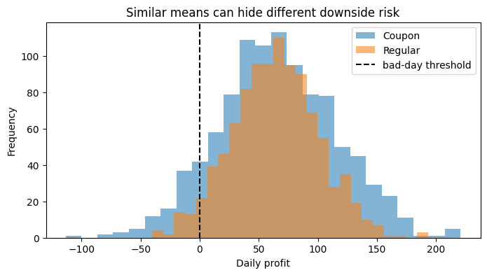

```python
fig, ax = plt.subplots(figsize=(8, 4))

for case, group in profit_demo.groupby("case"):
    ax.hist(group["profit"], bins=25, alpha=0.55, label=case)

ax.axvline(bad_day_threshold, color="black", linestyle="--", label="bad-day threshold")
ax.set_xlabel("Daily profit")
ax.set_ylabel("Frequency")
ax.set_title("Similar means can hide different downside risk")
ax.legend()
plt.show()
```

The estimated bad-day probability is the fraction of each histogram's area **to the left of the dashed line**. The coupon histogram is wider, so more of it falls below zero.

A bad-day threshold is a **modelling choice** and must be stated *before* simulating. Here "bad" means a loss (`profit < 0`); a real manager might choose a cash-flow target such as `profit < 20`. Lab 4 Part B asks you to fix this definition first.

**Question:** How many loss-making days is the Regular estimate actually based on? What does that suggest about how precisely a *small* probability can be estimated from 1,000 days?

## Demo 8: Confidence interval for mean profit — by hand first

We compute the 95% CI for $\mathbb E[H]$ under the **Regular** policy, one line at a time, exactly as in Demo 2.

$$ \bar H_n\pm1.96\,\frac{s_H}{\sqrt n}. $$

```python
values = regular_profits.to_numpy()
n = len(values)
n
```

```
1000
```

```python
mean = values.mean()
mean
```

```
np.float64(64.17226186850027)
```

```python
sample_sd = values.std(ddof=1)
sample_sd
```

```
np.float64(36.443400447707695)
```

```python
standard_error = sample_sd / np.sqrt(n)
standard_error
```

```
np.float64(1.1524415109635635)
```

```python
z = 1.96
margin = z * standard_error
lower = mean - margin
upper = mean + margin
print(f"estimate = {mean:.2f},  SE = {standard_error:.3f},  margin = {margin:.3f}")
print(f"95% CI for expected Regular profit: [{lower:.2f}, {upper:.2f}],  width = {upper - lower:.3f}")
```

```
estimate = 64.17,  SE = 1.152,  margin = 2.259
95% CI for expected Regular profit: [61.91, 66.43],  width = 4.518
```

**Interpretation (word it carefully).**

> "Under this model, the expected daily profit of the Regular policy is estimated at about [estimate]. An approximate 95% confidence interval is [lower, upper]. If we repeated this whole 1,000-day simulation many times, about 95% of intervals built this way would contain the model's true expected profit."

Notice how the numbers compare (DEMO_SEED = 6901): the **sample SD** of daily profits is about 36, but the **standard error** is only about 1.15 — smaller by the factor $\sqrt{1000}\approx31.6$. Daily profits vary a lot; our estimate of their *average* is precise.

We need exactly the same calculation for Coupon, and later for many other experiments. So *now* a function becomes useful.

```python
def mean_confidence_interval(values, z=1.96):
    """Approximate CI for the mean: mean +/- z * s / sqrt(n)."""
    values = np.asarray(values)
    mean = values.mean()
    sample_sd = values.std(ddof=1)
    standard_error = sample_sd / np.sqrt(len(values))
    lower = mean - z * standard_error
    upper = mean + z * standard_error
    return mean, sample_sd, standard_error, lower, upper, upper - lower
```

- `return a, b, c, ...` returns several values packed into one **tuple**.
- The caller **unpacks** them into separate names, in the same order — exactly like `case, assumptions = pair` in Demo 6.

Check against the manual calculation:

```python
mean_r, sd_r, se_r, lower_r, upper_r, width_r = mean_confidence_interval(regular_profits)
print("function:", round(lower_r, 4), round(upper_r, 4))
print("by hand :", round(lower, 4), round(upper, 4))
```

```
function: 61.9135 66.431
by hand : 61.9135 66.431
```

Now both cases, with a loop over the groups:

```python
ci_rows = []

for case, group in profit_demo.groupby("case"):
    mean, sample_sd, standard_error, lower, upper, width = mean_confidence_interval(group["profit"])
    ci_rows.append({
        "case": case,
        "mean": mean,
        "sample_sd": sample_sd,
        "standard_error": standard_error,
        "lower": lower,
        "upper": upper,
        "ci_width": width,
    })

ci_demo = pd.DataFrame(ci_rows).set_index("case")
ci_demo
```

| case | mean | sample_sd | standard_error | lower | upper | ci_width |
| --- | --- | --- | --- | --- | --- | --- |
| Coupon | 65.351159 | 49.674626 | 1.570850 | 62.272294 | 68.430024 | 6.157730 |
| Regular | 64.172262 | 36.443400 | 1.152442 | 61.913477 | 66.431047 | 4.517571 |

**Bonus: the same function gives a CI for a probability**, because a probability is a mean of 0/1 values.

```python
for case, group in profit_with_indicator.groupby("case"):
    p_hat, s, se, lo, hi, w = mean_confidence_interval(group["bad_day"].astype(int))
    print(f"{case:8s}: P(loss) estimate = {p_hat:.3f},  95% CI [{lo:.3f}, {hi:.3f}],  "
          f"sqrt(p(1-p)/n) = {np.sqrt(p_hat * (1 - p_hat) / len(group)):.4f},  SE from function = {se:.4f}")
```

```
Coupon  : P(loss) estimate = 0.095,  95% CI [0.077, 0.113],  sqrt(p(1-p)/n) = 0.0093,  SE from function = 0.0093
Regular : P(loss) estimate = 0.042,  95% CI [0.030, 0.054],  sqrt(p(1-p)/n) = 0.0063,  SE from function = 0.0063
```

### A CI for the mean is NOT a range for individual days

**Question:** "The Coupon CI is only a few units wide. Does that mean 95% of Coupon days have profit inside it?"

Test it directly: what fraction of the 1,000 simulated Coupon days fall inside the Coupon CI? And what range *does* contain the middle 95% of days?

```python
coupon_lower = ci_demo.loc["Coupon", "lower"]
coupon_upper = ci_demo.loc["Coupon", "upper"]
inside_ci = (coupon_profits >= coupon_lower) & (coupon_profits <= coupon_upper)

middle_95 = np.quantile(coupon_profits, [0.025, 0.975])

print(f"Coupon 95% CI for the MEAN            : [{coupon_lower:.2f}, {coupon_upper:.2f}]")
print(f"fraction of individual days inside it : {inside_ci.mean():.3f}")
print(f"range holding the middle 95% of DAYS  : [{middle_95[0]:.2f}, {middle_95[1]:.2f}]")
```

```
Coupon 95% CI for the MEAN            : [62.27, 68.43]
fraction of individual days inside it : 0.051
range holding the middle 95% of DAYS  : [-30.18, 163.20]
```

**Questions:**

1. What fraction of individual Coupon days fall inside the CI for the mean? Compare the width of the CI with the range that holds the middle 95% of days.
2. Does a narrow CI mean the business itself has low risk?

## Demo 9: How many replications? The $O(n^{-1/2})$ rate for the kiosk

**Predict first.** Suppose the SE for mean profit at $n=100$ is $a$. Using $\mathrm{SE}\propto1/\sqrt n$:

- at $n=1000$: SE $\approx$ ?
- at $n=10000$: SE $\approx$ ?

```python
stability_rows = []

for n_replications in [100, 1000, 10000]:
    experiment = run_kiosk_experiment(n_replications=n_replications, seed=DEMO_SEED)
    for case, group in experiment.groupby("case"):
        mean, sample_sd, standard_error, lower, upper, width = mean_confidence_interval(group["profit"])
        stability_rows.append({
            "replications": n_replications,
            "case": case,
            "mean": mean,
            "sample_sd": sample_sd,
            "standard_error": standard_error,
            "ci_width": width,
        })

stability_demo = pd.DataFrame(stability_rows)
stability_demo
```

|  | replications | case | mean | sample_sd | standard_error | ci_width |
| --- | --- | --- | --- | --- | --- | --- |
| 0 | 100 | Coupon | 65.475972 | 45.513997 | 4.551400 | 17.841487 |
| 1 | 100 | Regular | 69.028424 | 38.821937 | 3.882194 | 15.218199 |
| 2 | 1000 | Coupon | 65.351159 | 49.674626 | 1.570850 | 6.157730 |
| 3 | 1000 | Regular | 64.172262 | 36.443400 | 1.152442 | 4.517571 |
| 4 | 10000 | Coupon | 64.611350 | 51.332219 | 0.513322 | 2.012223 |
| 5 | 10000 | Regular | 64.484239 | 35.948871 | 0.359489 | 1.409196 |

Compare observed SE ratios with the theoretical ratios $\sqrt{n/100}$. First rearrange the SEs into a small table with one column per case:

```python
se_table = stability_demo.pivot(index="replications", columns="case", values="standard_error")
se_table
```

| case replications | Coupon | Regular |
| --- | --- | --- |
| 100 | 4.551400 | 3.882194 |
| 1000 | 1.570850 | 1.152442 |
| 10000 | 0.513322 | 0.359489 |

```python
ratio_table = se_table.iloc[0] / se_table
ratio_table["theory sqrt(n/100)"] = np.sqrt(se_table.index / 100)
ratio_table.round(3)
```

| case replications | Coupon | Regular | theory sqrt(n/100) |
| --- | --- | --- | --- |
| 100 | 1.000 | 1.000 | 1.000 |
| 1000 | 2.897 | 3.369 | 3.162 |
| 10000 | 8.867 | 10.799 | 10.000 |

**Questions:**

1. How close are the observed SE ratios to the theoretical $\sqrt{10}\approx3.162$ and $10$? Give one reason they are not exactly equal.
2. Look at the `sample_sd` column in the previous table. Does it shrink as $n$ grows? Which quantity does?

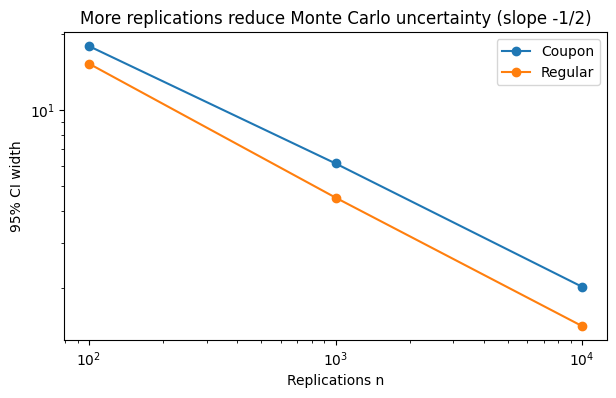

```python
fig, ax = plt.subplots(figsize=(7, 4))

for case, group in stability_demo.groupby("case"):
    ax.plot(group["replications"], group["ci_width"], marker="o", label=case)

ax.set_xscale("log")
ax.set_yscale("log")
ax.set_xlabel("Replications n")
ax.set_ylabel("95% CI width")
ax.set_title("More replications reduce Monte Carlo uncertainty (slope -1/2)")
ax.legend()
plt.show()
```

The widths shrink roughly as $1/\sqrt n$ (a straight line of slope $-1/2$ on log–log axes). **More replications reduce simulation noise; they cannot repair unrealistic demand, spending, cost or capacity assumptions.**

## Demo 9b: Does the CLT apply to the kiosk?

Demo 3 showed the bell shape for an integral, which invites a fair objection: "that says nothing about the business". So we rerun the **whole** 1,000-replication Coupon experiment 200 times and look at the 200 answers we could have reported.

Two levels of repetition:

```
experiment 1:   day 1, day 2, ..., day 1000   ->  mean of 1000 profits  ->  one estimate  H-bar^(1)
experiment 2:   day 1, day 2, ..., day 1000   ->  one estimate  H-bar^(2)
...
experiment 200: day 1, day 2, ..., day 1000   ->  one estimate  H-bar^(200)
```

### The explicit nested loop (read this version first)

```python
kiosk_repeat_rng = np.random.default_rng(DEMO_SEED)
coupon_means = []
coupon_bad_fractions = []

for experiment in range(200):
    daily_profits = []
    for day in range(1000):
        profit = simulate_kiosk_day(coupon, kiosk_repeat_rng)
        daily_profits.append(profit)
    experiment_mean = np.mean(daily_profits)
    coupon_means.append(experiment_mean)
    coupon_bad_fractions.append(np.mean(np.array(daily_profits) < 0))

coupon_means = np.array(coupon_means)
coupon_bad_fractions = np.array(coupon_bad_fractions)
print("number of estimates:", len(coupon_means))
print("first five estimates:", coupon_means[:5].round(2))
```

```
number of estimates: 200
first five estimates: [68.16 66.52 63.54 66.75 65.09]
```

Every level has a meaning:

| Code | Meaning |
| --- | --- |
| inner loop over `day` | the individual simulated days $H_1,\dots,H_{1000}$ |
| `experiment_mean` | one Monte Carlo estimate $\bar H_{1000}$ |
| outer loop over `experiment` | repeating the **entire** experiment |
| `coupon_means` | 200 draws from the **sampling distribution** of the estimator $\bar H_{1000}$ |

`daily_profits = []` is *inside* the outer loop on purpose: each experiment must start with an empty list.

**Question:** What would go wrong if `daily_profits = []` were written once, *before* the outer loop?

### Does the spread of the 200 estimates match the CLT prediction?

```python
coupon_sd = coupon_profits.std()

pd.Series({
    "mean of the 200 reported means": coupon_means.mean(),
    "SD of the 200 reported means (observed)": coupon_means.std(ddof=1),
    "CLT prediction  s_H / sqrt(1000)": coupon_sd / np.sqrt(1000),
    "SD of individual Coupon days  s_H": coupon_sd,
}).round(4)
```

```
mean of the 200 reported means             65.0235
SD of the 200 reported means (observed)     1.5285
CLT prediction  s_H / sqrt(1000)            1.5708
SD of individual Coupon days  s_H          49.6746
dtype: float64
```

**Question:** How close is the observed SD of the 200 means to the CLT prediction $s_H/\sqrt{1000}$? How does it compare with the SD of individual days?

### The side-by-side picture — one of the most important in the course

**Question (think before running the next cells):** "What exactly is one observation in the left histogram? In the right histogram?"

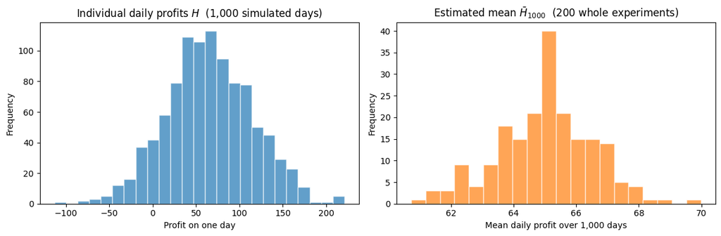

```python
fig, axes = plt.subplots(1, 2, figsize=(12, 4))

axes[0].hist(coupon_profits, bins=25, alpha=0.7, color="tab:blue", edgecolor="white")
axes[0].set_title(r"Individual daily profits $H$  (1,000 simulated days)")
axes[0].set_xlabel("Profit on one day")

axes[1].hist(coupon_means, bins=20, alpha=0.7, color="tab:orange", edgecolor="white")
axes[1].set_title(r"Estimated mean $\bar H_{1000}$  (200 whole experiments)")
axes[1].set_xlabel("Mean daily profit over 1,000 days")

for ax in axes:
    ax.set_ylabel("Frequency")
plt.tight_layout()
plt.show()
```

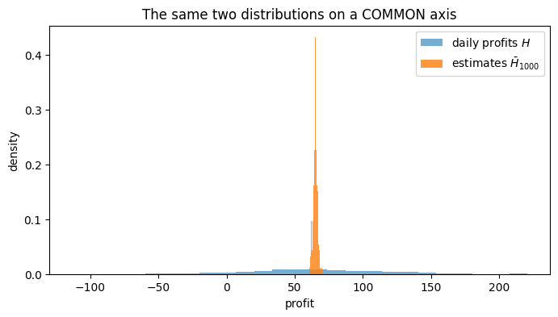

```python
fig, ax = plt.subplots(figsize=(8, 4))
ax.hist(coupon_profits, bins=25, density=True, alpha=0.6, color="tab:blue", label=r"daily profits $H$")
ax.hist(coupon_means, bins=20, density=True, alpha=0.8, color="tab:orange", label=r"estimates $\bar H_{1000}$")
ax.set_xlabel("profit")
ax.set_ylabel("density")
ax.set_title("The same two distributions on a COMMON axis")
ax.legend()
plt.show()
```

On a common axis the sampling distribution is a thin spike inside the wide distribution of daily profits: its SD is $\sqrt{1000}\approx32$ times smaller.

**An honest caveat about shape.** In this particular model the daily profit $H$ is itself close to Normal (its sample skewness is essentially 0), because profit is dominated by the Normal demand draw. So the kiosk picture above demonstrates the **width** part of the CLT ($\sigma/\sqrt n$) convincingly, but not the **shape** part — both histograms are bell-shaped for different reasons. The shape part was shown in Demo 3 with the skewed $e^U$. To see it for the kiosk, use an output that is *obviously* non-Normal: the bad-day indicator $\mathbf 1\{H<0\}$, which takes only the values 0 and 1.

| Feature | Individual profit $H$ | Estimated mean $\bar H_n$ |
| --- | --- | --- |
| What is one observation? | one simulated day | one whole Monte Carlo experiment ($n$ days) |
| Centre | $\mathbb E[H]$ | $\mathbb E[H]$ |
| SD | $\sigma_H$ | $\sigma_H/\sqrt n$ |
| Shape | whatever the model produces (here close to Normal; for the indicator below, two spikes at 0 and 1) | approximately Normal, by the CLT |
| Meaning | **business variability**: how different one day is from another | **Monte Carlo estimation uncertainty**: how much our reported answer would move if we reran the study |
| Described by | SD of daily profit, $\mathbb P(H<0)$ | SE, confidence interval |

**Questions:**

1. "The coupon CI for the mean is a few units wide. Does that mean 95% of days fall in a few-unit range?"
2. "Why can daily profits be non-Normal while the sample means look Normal?"

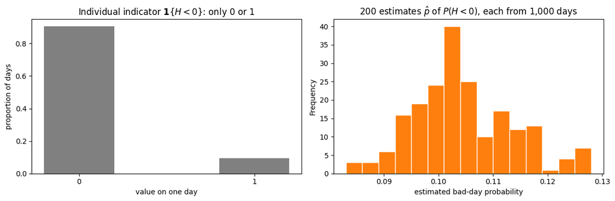

```
SD of the 200 estimates p-hat: 0.0093
CLT prediction sqrt(p(1-p)/1000) with p = 0.104: 0.0097
```

```python
coupon_indicator = (coupon_profits < 0).astype(int)

fig, axes = plt.subplots(1, 2, figsize=(12, 4))
axes[0].bar([0, 1], [np.mean(coupon_indicator == 0), np.mean(coupon_indicator == 1)],
            width=0.4, color="grey")
axes[0].set_xticks([0, 1])
axes[0].set_title(r"Individual indicator $\mathbf{1}\{H<0\}$: only 0 or 1")
axes[0].set_xlabel("value on one day")
axes[0].set_ylabel("proportion of days")

axes[1].hist(coupon_bad_fractions, bins=15, color="tab:orange", edgecolor="white")
axes[1].set_title(r"200 estimates $\hat p$ of $P(H<0)$, each from 1,000 days")
axes[1].set_xlabel("estimated bad-day probability")
axes[1].set_ylabel("Frequency")
plt.tight_layout()
plt.show()

p_bar = coupon_bad_fractions.mean()
print(f"SD of the 200 estimates p-hat: {coupon_bad_fractions.std(ddof=1):.4f}")
print(f"CLT prediction sqrt(p(1-p)/1000) with p = {p_bar:.3f}: {np.sqrt(p_bar * (1 - p_bar) / 1000):.4f}")
```

Here the contrast is unmistakable: one observation of the indicator is 0 or 1 — as far from Normal as a distribution can be — yet the average of 1,000 of them is bell-shaped around $\mathbb P(H<0)\approx0.1$, with SD close to $\sqrt{p(1-p)/1000}$. **This** is the shape part of the CLT, for the kiosk.

### Optional: the compact version with list comprehensions

The same nested loop can be written in one expression using **list comprehensions**. It is equivalent, but harder for beginners to read, so the explicit loop above is the version to learn from.

```
coupon_means = np.array([
    np.mean([simulate_kiosk_day(coupon, kiosk_repeat_rng) for _ in range(1000)])
    for _ in range(200)
])
```

`[expression for _ in range(k)]` means "evaluate `expression` $k$ times and collect the results in a list". Check equivalence on the first five experiments (restarting the same stream):

```python
check_rng = np.random.default_rng(DEMO_SEED)
compact_first_five = np.array([
    np.mean([simulate_kiosk_day(coupon, check_rng) for _ in range(1000)])
    for _ in range(5)
])
print(compact_first_five.round(4))
print(coupon_means[:5].round(4))
print("identical?", np.allclose(compact_first_five, coupon_means[:5]))
```

```
[68.1637 66.5224 63.5364 66.7524 65.0947]
[68.1637 66.5224 63.5364 66.7524 65.0947]
identical? True
```

## Demo 10: Controlled sensitivity to the campaign cost

**Question:** how do mean profit and loss probability change if the coupon campaign costs 0, 15, 30, 45 or 60?

We do one comparison (cost 0 versus cost 15) by hand before writing a loop. Along the way we need two Python ideas: **copying a dictionary**, and **resetting a seed on purpose**.

### Python lesson: why `.copy()`?

We want a *modified* coupon scenario without damaging the original `coupon`. A toy example shows the danger.

```python
toy = {"campaign_cost": 30}
alias = toy
alias["campaign_cost"] = 15
print("toy after changing alias:", toy)
```

```
toy after changing alias: {'campaign_cost': 15}
```

```python
toy = {"campaign_cost": 30}
safe_copy = toy.copy()
safe_copy["campaign_cost"] = 15
print("toy after changing safe_copy:", toy)
print("safe_copy:", safe_copy)
```

```
toy after changing safe_copy: {'campaign_cost': 30}
safe_copy: {'campaign_cost': 15}
```

If we wrote `changed_coupon = coupon` and then changed `changed_coupon["campaign_cost"]`, we would silently change `coupon` itself, and every later cell that uses `coupon` would use the wrong campaign cost.

### Cost 0 versus cost 15, by hand

We will need "simulate many days and collect the profits" several times, so we first write that loop once more — explicitly.

```python
coupon_cost_0 = coupon.copy()
coupon_cost_0["campaign_cost"] = 0

rng_cost_0 = np.random.default_rng(DEMO_SEED)
profits_cost_0 = []
for day in range(2000):
    profits_cost_0.append(simulate_kiosk_day(coupon_cost_0, rng_cost_0))
profits_cost_0 = np.array(profits_cost_0)

print(f"campaign cost  0: mean profit = {profits_cost_0.mean():.3f},  P(loss) = {np.mean(profits_cost_0 < 0):.4f}")
```

```
campaign cost  0: mean profit = 97.343,  P(loss) = 0.0285
```

```python
coupon_cost_15 = coupon.copy()
coupon_cost_15["campaign_cost"] = 15

rng_cost_15 = np.random.default_rng(DEMO_SEED)
profits_cost_15 = []
for day in range(2000):
    profits_cost_15.append(simulate_kiosk_day(coupon_cost_15, rng_cost_15))
profits_cost_15 = np.array(profits_cost_15)

print(f"campaign cost 15: mean profit = {profits_cost_15.mean():.3f},  P(loss) = {np.mean(profits_cost_15 < 0):.4f}")
```

```
campaign cost 15: mean profit = 82.343,  P(loss) = 0.0575
```

```python
day_by_day_difference = profits_cost_15 - profits_cost_0
print("first five day-by-day differences:", day_by_day_difference[:5])
print("difference in mean profit        :", profits_cost_15.mean() - profits_cost_0.mean())
print("every day exactly 15 lower?      :", np.allclose(day_by_day_difference, -15))
```

```
first five day-by-day differences: [-15. -15. -15. -15. -15.]
difference in mean profit        : -15.0
every day exactly 15 lower?      : True
```

**What happened?** Because both runs started from the same seed, and campaign cost does not affect any random draw, the two runs simulated **the same 2,000 days** — same demand, same spending — and the only difference is the campaign cost. Every day is exactly 15 lower, so the difference in means is exactly 15, with **no Monte Carlo noise at all** in the comparison.

### Compare: the same comparison with *independent* streams

```python
rng_a = np.random.default_rng(1001)
rng_b = np.random.default_rng(2002)
indep_0 = []
indep_15 = []
for day in range(2000):
    indep_0.append(simulate_kiosk_day(coupon_cost_0, rng_a))
    indep_15.append(simulate_kiosk_day(coupon_cost_15, rng_b))
indep_0 = np.array(indep_0)
indep_15 = np.array(indep_15)

se_difference = np.sqrt(indep_0.var(ddof=1) / 2000 + indep_15.var(ddof=1) / 2000)
print(f"independent streams: difference in mean profit = {indep_15.mean() - indep_0.mean():.3f}   (true effect: -15)")
print(f"SE of that difference is about {se_difference:.2f}")
```

```
independent streams: difference in mean profit = -14.130   (true effect: -15)
SE of that difference is about 1.67
```

With independent streams the estimated effect is $-15$ **plus noise** of a couple of units, because the two runs saw different random days. With the same seed, the comparison isolates the effect of the one parameter we changed.

### Good seed resetting versus bad seed resetting

|  | **Bad**: resetting inside every simulated day | **Deliberate**: same seed for each scenario being compared |
| --- | --- | --- |
| What is reset | the generator, at the start of *every replication* | the generator, at the start of *each whole scenario run* |
| Effect | every "replication" is the same day; $s=0$, CI width 0 — fake certainty | each scenario sees the same sequence of random days |
| Purpose | none — it is a bug | a **controlled comparison** (also called *common random numbers*): differences are attributable to the changed parameter |

Here is the bug, so that you can recognise it:

```python
def buggy_simulate_kiosk_day(assumptions):
    rng = np.random.default_rng(DEMO_SEED)
    return simulate_kiosk_day(assumptions, rng)

buggy_profits = []
for day in range(5):
    buggy_profits.append(buggy_simulate_kiosk_day(coupon))

print("five 'different' days:", np.round(buggy_profits, 3))
print("sample SD of these days:", np.std(buggy_profits, ddof=1))
```

```
five 'different' days: [75.061 75.061 75.061 75.061 75.061]
sample SD of these days: 0.0
```

Five identical days, SD 0, so the "confidence interval" would have width 0 — a precise answer to the wrong question.

### Only now: the loop over campaign costs

```python
sensitivity_rows = []

for campaign_cost in [0, 15, 30, 45, 60]:
    changed_coupon = coupon.copy()
    changed_coupon["campaign_cost"] = campaign_cost
    sensitivity_rng = np.random.default_rng(DEMO_SEED)
    profits = []
    for day in range(2000):
        profits.append(simulate_kiosk_day(changed_coupon, sensitivity_rng))
    profits = np.array(profits)
    sensitivity_rows.append({
        "campaign_cost": campaign_cost,
        "mean_profit": profits.mean(),
        "bad_day_probability": np.mean(profits < 0),
    })

sensitivity_demo = pd.DataFrame(sensitivity_rows)
sensitivity_demo
```

|  | campaign_cost | mean_profit | bad_day_probability |
| --- | --- | --- | --- |
| 0 | 0 | 97.343049 | 0.0285 |
| 1 | 15 | 82.343049 | 0.0575 |
| 2 | 30 | 67.343049 | 0.0985 |
| 3 | 45 | 52.343049 | 0.1580 |
| 4 | 60 | 37.343049 | 0.2300 |

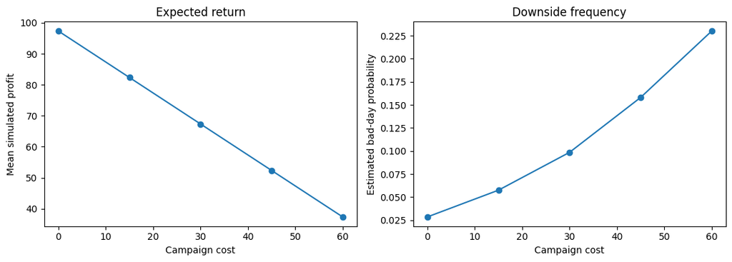

```python
fig, axes = plt.subplots(1, 2, figsize=(11, 4))

axes[0].plot(sensitivity_demo["campaign_cost"], sensitivity_demo["mean_profit"], marker="o")
axes[0].set_xlabel("Campaign cost")
axes[0].set_ylabel("Mean simulated profit")
axes[0].set_title("Expected return")

axes[1].plot(sensitivity_demo["campaign_cost"], sensitivity_demo["bad_day_probability"], marker="o")
axes[1].set_xlabel("Campaign cost")
axes[1].set_ylabel("Estimated bad-day probability")
axes[1].set_title("Downside frequency")

plt.tight_layout()
plt.show()
```

**Questions:**

1. Check that the first two rows match the by-hand cost-0 and cost-15 runs above.
2. By how much does mean profit fall for each extra 15 of campaign cost? Why is the fall *exactly* the same at every step?
3. Does the loss probability rise linearly with the campaign cost? Why or why not?
4. Earlier we said that resetting the seed is a bug. Why is it legitimate to reset it here?

## Demo 11: A strong interpretation

The evidence from Demos 6–8 (DEMO_SEED = 6901, 1,000 days per case):

|  | Regular | Coupon |
| --- | --- | --- |
| estimated mean profit | 64.2 | 65.4 |
| 95% CI for mean profit | [61.9, 66.4] | [62.3, 68.4] |
| SD of daily profit | 36 | 50 |
| estimated $\mathbb P(\text{loss})$ | 0.042 [0.030, 0.054] | 0.095 [0.077, 0.113] |

The two CIs for mean profit overlap heavily: at this $n$ the simulation cannot tell the two expected profits apart. The loss probabilities, by contrast, are clearly different — their CIs do not overlap.

> Under this model, the coupon and regular cases have similar estimated mean profit, but the coupon has a much wider daily-profit distribution and a higher probability of loss. I would not adopt the coupon unchanged. I would test a lower campaign cost or run a short pilot, then replace the assumed demand response with observed transaction data. This conclusion is conditional on the Normal demand and spending assumptions and ignores queue capacity and customers who leave.

A strong recommendation connects **five** things:

1. **expected return** — the estimated $\mathbb E[H]$ for each option;
2. **downside risk** — the estimated $\mathbb P(H<0)$ (and the spread of daily profit);
3. **Monte Carlo uncertainty** — the confidence intervals: are the two means distinguishable given the SEs?
4. **model limitations** — which assumptions could be wrong, and which direction that would push the answer;
5. **a practical next action** — pilot, collect data, test a cheaper campaign.

Points 3 and 4 are different kinds of uncertainty. Point 3 shrinks with more replications; point 4 does not.

## Final theory map

$$ X_i\;\longrightarrow\;Y_i=h(X_i) \qquad\qquad Y_1,\dots,Y_n\;\longrightarrow\;\bar Y_n=\frac1n\sum_{i=1}^nY_i $$

**LLN** (where the estimate goes): $$ \bar Y_n\to\mathbb E[Y]. $$

**Variance of the mean** (from independence): $$ \mathrm{Var}(\bar Y_n)=\frac{\mathrm{Var}(Y)}{n}. $$

**CLT** (how the estimate is spread): $$ \bar Y_n\approx N\!\left(\mathbb E[Y],\ \frac{\mathrm{Var}(Y)}{n}\right). $$

**Estimated standard error:** $$ \mathrm{SE}=\frac{s}{\sqrt n},\qquad s^2=\frac1{n-1}\sum(Y_i-\bar Y)^2 \quad(\texttt{ddof=1}). $$

**Approximate 95% CI:** $$ \bar Y_n\pm1.96\,\mathrm{SE},\qquad \mathbb P(-1.96<Z<1.96)\approx0.95. $$

**Rate:** $\mathrm{SE}=O(n^{-1/2})$ — 4× replications halves the SE, 100× gives one more decimal place.

**Probability as an expectation:** for an event $A$, $$ \mathbb P(A)=\mathbb E[\mathbf 1_A],\qquad \hat p=\frac1n\sum_{i=1}^n\mathbf 1_{A,i}. $$

### The same formulas in the three problems of this demo

|  | $X$ | $Y=h(X)$ | target | estimator |
| --- | --- | --- | --- | --- |
| Monte Carlo integration | $U\sim\mathrm{U}(0,1)$ | $e^U$ | $\int_0^1e^u\,du=e-1$ | $\frac1n\sum e^{U_i}$ |
| Mean kiosk profit | demand and spends for one day | profit $H$ | $\mathbb E[H]$ | $\bar H_n$ |
| Probability of a loss-making day | demand and spends for one day | $\mathbf 1\{H<0\}$ | $\mathbb P(H<0)$ | fraction of simulated days with $H<0$ |

In all three rows: the LLN justifies the estimator, the CLT justifies the error bar $\pm1.96\,s/\sqrt n$, and the error shrinks like $n^{-1/2}$.

### Distinctions to leave with

| This … | … is not this |
| --- | --- |
| one output $H_i$ | the expected output $\mathbb E[H]$ |
| sample SD $s_H$ (variation of days) | standard error $s_H/\sqrt n$ (uncertainty of the mean) |
| distribution of $H$ | sampling distribution of $\bar H_n$ |
| LLN: $\bar H_n\to\mathbb E[H]$ | CLT: $\frac{\bar H_n-\mu}{\sigma/\sqrt n}\approx N(0,1)$ |
| CI for $\mathbb E[H]$ | a range containing 95% of daily profits |
| Monte Carlo error (shrinks with $n$) | model error (does not) |
| clipping `max(0, x)` | sampling from a truncated Normal |

## Final coding map

```
One random draw
    ↓
One model output                         u_small, h_small            (Demo 1)
    ↓                                     raw_demand → demand → profit (Demo 5)
Repeat manually a few times              n = 10 block, n = 100 block (Demo 2)
    ↓                                     profit_1, profit_2, profit_3 (Demo 6)
Loop                                     for n in [...]:  /  for replication in range(1, 6):
    ↓
Same calculation needed repeatedly
    ↓
Function                                 repeated_estimates, simulate_kiosk_day,
    ↓                                     run_kiosk_experiment, mean_confidence_interval
Many outputs
    ↓
Mean / SD / probability                  .mean(), .std(ddof=1), (profit < 0).mean(), groupby
    ↓
Repeat the entire experiment             outer loop in Demo 3 and Demo 9b
    ↓
Sampling distribution
    ↓
CLT / SE / confidence interval           s / sqrt(n),  estimate ± 1.96 SE,  coverage
```

**Rule of thumb for your own code:** write the long, readable version first; print the intermediate values; check them against the mathematics; only then wrap the calculation in a loop or function — and test the function on a tiny case before using it at scale.

## Before you start Lab 4

You should now be able to explain:

1. what $X$, $h(X)$ and $\mathbb E[h(X)]$ mean in an integration or profit problem;
2. why one simulated day is not a decision;
3. why the LLN makes the average converge, and why the error need not fall at every step;
4. the difference between the sample SD and the standard error, and why we use `ddof=1`;
5. that a Monte Carlo estimate is **itself random**, approximately Normal about the true value with SD $\sigma_h/\sqrt n$ (CLT);
6. what "95% confident" claims — the *interval* is random and captures the fixed target about 95% of the time;
7. why a confidence interval for the mean is not a range for individual days;
8. how an indicator average estimates a probability;
9. why interval width shrinks approximately as $1/\sqrt n$, so 100 times the replications buys 10 times the precision;
10. why more replications cannot validate unrealistic assumptions.

Items 5, 6 and 9 are assessed in Lab 4 parts A2, A3 and F. Do not skip Demos 3 and 9b.

The daily-profit model in the lab is **provided already written**. You read, run and explain it rather than building it — Demo 5 is your preparation for that.

## Common errors

- Resetting the generator inside the daily simulation function, which repeats the same day (Demo 10).
- Treating one simulated output as an expected value.
- Reading the spread of *individual daily profits* off the confidence interval for the *mean*, or the reverse — the two histograms in Demo 9b are the cure.
- Expecting the sampling distribution of the estimate to look like the distribution of the underlying outputs.
- Allowing negative demand or spending without explanation, or calling the clipping "truncation".
- Comparing only mean profit and ignoring downside risk.
- Using NumPy's default `std()` (ddof = 0) instead of the sample SD (`ddof=1`) in the confidence interval.
- Confusing sample SD with the standard error of the mean.
- Saying "there is a 95% chance the true value lies in this interval" instead of describing the procedure's long-run coverage.
- Assuming absolute integration error must fall monotonically as $n$ grows.
- Claiming that more replications validate the model assumptions.
- Changing a scenario dictionary without `.copy()`, which silently changes the original.
- Changing several assumptions at once and attributing the result to one input.